# ST2195 Coursework

## Libraries

For this project to work in R, the libraries below are required.

```r
library(DBI)
library(dplyr)
library(tidyverse)
library(reshape2)
```

```r
library(ggplot2)
```

## Database Creation

First, we will set up a database to hold all the data contained in the csv files.

```r
###################DATABASE CREATION########################
#Check if database exists
setwd("E:/ST2195/Coursework/")
if (file.exists("airline2.db")) {
  file.remove("airline2.db")
  cat("File deleted.")
} else {
  cat("File does not exist.")
}
```

```
## File deleted.
```

```r
#Create database and connect
conn <- dbConnect(RSQLite::SQLite(), "airline2.db")

#Create data frames.
#Note: The code below binds all csv files in the folder into one dataframe. If more datasets are needed, simply add them into the folder 'ontime'.
setwd("E:/ST2195/Coursework/datasets/ontime/")
csv_ontime <- dir("E:/ST2195/Coursework/datasets/ontime/")
ontime <- do.call(rbind,lapply(csv_ontime,read.csv))

setwd("E:/ST2195/Coursework/datasets/")
airports <- read.csv("airports.csv", header=TRUE)
carriers <- read.csv("carriers.csv", header=TRUE)
planes <- read.csv("plane-data.csv", header=TRUE)

#Copy data frames and put in database as tables
dbWriteTable(conn, "ONTIME", ontime)
dbWriteTable(conn, "AIRPORTS", airports)
dbWriteTable(conn, "CARRIERS", carriers)
dbWriteTable(conn, "PLANES", planes)

cat("Database established.")
```

```
## Database established.
```

## Sub-setting the ontime table

Not all variables are necessary for this project, so we will drop them. The following were dropped:  
ActualElapse  
CRSActualElapse  
TaxiIn  
TaxiOut  
CarrierDelay  
NASDelay  
WeatherDelay  
SecurityDelay

We will also create two new variables – `FlightDate` and `Day` – as we will need them to answer the first question.

It will be better to do this after creating a sample because that would be more efficient and less computer-intensive, however for better clarity and presentation later, it will be done at this part in the process.

```r
######################SUB-SETTING###########################
#Check for missing values
summary(ontime)
```

```
##       Year          Month          DayofMonth      DayOfWeek
##  Min.   :2004   Min.   : 1.000   Min.   : 1.00   Min.   :1.000
##  1st Qu.:2004   1st Qu.: 4.000   1st Qu.: 8.00   1st Qu.:2.000
##  Median :2005   Median : 7.000   Median :16.00   Median :4.000
##  Mean   :2005   Mean   : 6.515   Mean   :15.74   Mean   :3.944
##  3rd Qu.:2005   3rd Qu.: 9.000   3rd Qu.:23.00   3rd Qu.:6.000
##  Max.   :2005   Max.   :12.000   Max.   :31.00   Max.   :7.000
##
##     DepTime         CRSDepTime      ArrTime         CRSArrTime
##  Min.   :   1     Min.   :   0   Min.   :   1     Min.   :   0
##  1st Qu.: 935     1st Qu.: 932   1st Qu.:1116     1st Qu.:1122
##  Median :1331     Median :1329   Median :1520     Median :1524
##  Mean   :1346     Mean   :1339   Mean   :1494     Mean   :1502
##  3rd Qu.:1735     3rd Qu.:1725   3rd Qu.:1915     3rd Qu.:1912
##  Max.   :2805     Max.   :2359   Max.   :2955     Max.   :2400
##  NA's   :261487                  NA's   :289299
##  UniqueCarrier        FlightNum      TailNum          ActualElapsedTime
##  Length:14269866    Min.   :   1   Length:14269866    Min.   :-710.0
##  Class :character   1st Qu.: 588   Class :character   1st Qu.:  73.0
##  Mode  :character   Median :1429   Mode  :character   Median : 105.0
##                     Mean   :2067                      Mean   : 124.1
##                     3rd Qu.:3185                      3rd Qu.: 155.0
##                     Max.   :9912                      Max.   :1849.0
##                                                       NA's   :289299
##  CRSElapsedTime      AirTime           ArrDelay           DepDelay
##  Min.   : -64.0   Min.   :-3818.0   Min.   :-1302.00   Min.   :-1199.00
##  1st Qu.:  75.0   1st Qu.:   53.0   1st Qu.:   -9.00   1st Qu.:   -4.00
##  Median : 105.0   Median :   84.0   Median :   -1.00   Median :    0.00
##  Mean   : 125.2   Mean   :  101.8   Mean   :    6.84   Mean   :    8.28
##  3rd Qu.: 155.0   3rd Qu.:  133.0   3rd Qu.:   10.00   3rd Qu.:    7.00
##  Max.   :1374.0   Max.   : 1956.0   Max.   : 1925.00   Max.   : 1930.00
##                   NA's   :289299    NA's   :289299     NA's   :261487
##     Origin              Dest              Distance          TaxiIn
##  Length:14269866    Length:14269866    Min.   :   6.0   Min.   :   0.000
##  Class :character   Class :character   1st Qu.: 308.0   1st Qu.:   4.000
##  Mode  :character   Mode  :character   Median : 551.0   Median :   5.000
##                                        Mean   : 718.7   Mean   :   7.707
##                                        3rd Qu.: 946.0   3rd Qu.:   7.000
##                                        Max.   :4962.0   Max.   :1523.000
##
```

[output cut: 9 more lines]

```
##  Min.   :   0.000   Min.   :   0.0000   Min.   : -49.0   Min.   :  0.0000
##  1st Qu.:   0.000   1st Qu.:   0.0000   1st Qu.:   0.0   1st Qu.:  0.0000
##  Median :   0.000   Median :   0.0000   Median :   0.0   Median :  0.0000
##  Mean   :   2.822   Mean   :   0.6833   Mean   :   3.4   Mean   :  0.0224
##  3rd Qu.:   0.000   3rd Qu.:   0.0000   3rd Qu.:   0.0   3rd Qu.:  0.0000
##  Max.   :1925.000   Max.   :1510.0000   Max.   :1380.0   Max.   :533.0000
##
##  LateAircraftDelay
##  Min.   :   0.000
##  1st Qu.:   0.000
##  Median :   0.000
##  Mean   :   3.555
##  3rd Qu.:   0.000
##  Max.   :1358.000
##
```

```r
summary(airports)
```

```
##      iata             airport              city              state
##  Length:3376        Length:3376        Length:3376        Length:3376
##  Class :character   Class :character   Class :character   Class :character
##  Mode  :character   Mode  :character   Mode  :character   Mode  :character
##
##
##
##    country               lat              long
##  Length:3376        Min.   : 7.367   Min.   :-176.65
##  Class :character   1st Qu.:34.688   1st Qu.:-108.76
##  Mode  :character   Median :39.434   Median : -93.60
##                     Mean   :40.037   Mean   : -98.62
##                     3rd Qu.:43.373   3rd Qu.: -84.14
##                     Max.   :71.285   Max.   : 145.62
```

```r
summary(planes)
```

```
##    tailnum              type           manufacturer        issue_date
##  Length:5029        Length:5029        Length:5029        Length:5029
##  Class :character   Class :character   Class :character   Class :character
##  Mode  :character   Mode  :character   Mode  :character   Mode  :character
##     model              status          aircraft_type      engine_type
##  Length:5029        Length:5029        Length:5029        Length:5029
##  Class :character   Class :character   Class :character   Class :character
##  Mode  :character   Mode  :character   Mode  :character   Mode  :character
##      year
##  Length:5029
##  Class :character
##  Mode  :character
```

```r
#Sub-setting relevant variables
ontime2 <- ontime[c(1:11,15:19,22:24,29)]

#Create new variable and column named FlightDate
date <- paste(ontime2$Month, ontime2$DayofMonth, ontime2$Year, sep="/")
date2 <- as.Date(date, format="%m/%d/%Y")
ontime2$FlightDate <- date2
#Add Day variable
ontime2$Day <- as.factor(weekdays(ontime2$FlightDate))
```

## Creating a sample

The ontime table is too large with 14 million observations. Using the table as-is will require a long processing time when running the code as well as a large memory, so for efficiency’s sake, we will draw a sample. This will done with the stratified sampling method because after exploring and analysing the data, I have found that the days act as subgroups, and I want a sample that best represents the population, i.e. the original table.

```r
#Check frequency of flights on certain days
table(ontime2$Day)
```

```
##
##    Friday    Monday  Saturday    Sunday  Thursday   Tuesday Wednesday
##   2112432   2093476   1823249   1981834   2107994   2071152   2079729
```

```r
#Drawing a stratified sample of roughly 200,000 with proportional size for each day
table(ontime2$Day)/nrow(ontime2) * 200000
```

```
##
##    Friday    Monday  Saturday    Sunday  Thursday   Tuesday Wednesday
##  29606.89  29341.21  25553.83  27776.49  29544.69  29028.33  29148.54
```

```r
set.seed(7)
o <- ontime2 %>%
  group_by(Day, Month) %>%
  sample_frac(size=.0144)
#Checking if proportions are similar to population as well as being an accurate representation of it
nrow(o)
```

```
## [1] 205486
```

```r
table(o$Day)
```

```
##
##    Friday    Monday  Saturday    Sunday  Thursday   Tuesday Wednesday
##     30419     30145     26255     28540     30355     29825     29947
```

```r
table(o$Month)
```

```
##
##     1     2     3     4     5     6     7     8     9    10    11    12
## 16975 15828 17553 16955 17413 17251 17887 18059 16696 17319 16571 16979
```

```r
summary(o)
```

```
##       Year          Month          DayofMonth      DayOfWeek        DepTime
##  Min.   :2004   Min.   : 1.000   Min.   : 1.00   Min.   :1.000   Min.   :   1
##  1st Qu.:2004   1st Qu.: 4.000   1st Qu.: 8.00   1st Qu.:2.000   1st Qu.: 935
##  Median :2004   Median : 7.000   Median :16.00   Median :4.000   Median :1330
##  Mean   :2004   Mean   : 6.516   Mean   :15.73   Mean   :3.944   Mean   :1345
##  3rd Qu.:2005   3rd Qu.: 9.000   3rd Qu.:23.00   3rd Qu.:6.000   3rd Qu.:1734
##  Max.   :2005   Max.   :12.000   Max.   :31.00   Max.   :7.000   Max.   :2631
##                                                                  NA's   :3739
##    CRSDepTime      ArrTime       CRSArrTime   UniqueCarrier        FlightNum
##  Min.   :   3   Min.   :   1   Min.   :   0   Length:205486      Min.   :   1
##  1st Qu.: 934   1st Qu.:1116   1st Qu.:1121   Class :character   1st Qu.: 582
##  Median :1326   Median :1519   Median :1522   Mode  :character   Median :1425
##  Mean   :1339   Mean   :1493   Mean   :1501                      Mean   :2065
##  3rd Qu.:1725   3rd Qu.:1914   3rd Qu.:1910                      3rd Qu.:3185
##  Max.   :2359   Max.   :2728   Max.   :2359                      Max.   :9584
##                 NA's   :4129
##    TailNum             ArrDelay           DepDelay           Origin
##  Length:205486      Min.   : -73.000   Min.   :-1151.00   Length:205486
##  Class :character   1st Qu.:  -9.000   1st Qu.:   -4.00   Class :character
##  Mode  :character   Median :  -1.000   Median :    0.00   Mode  :character
##                     Mean   :   6.746   Mean   :    8.18
##                     3rd Qu.:  10.000   3rd Qu.:    7.00
##                     Max.   :1307.000   Max.   : 1316.00
##                     NA's   :4129       NA's   :3739
##      Dest              Distance        Cancelled      CancellationCode
##  Length:205486      Min.   :  27.0   Min.   :0.0000   Length:205486
##  Class :character   1st Qu.: 308.0   1st Qu.:0.0000   Class :character
##  Mode  :character   Median : 549.0   Median :0.0000   Mode  :character
##                     Mean   : 716.1   Mean   :0.0182
##                     3rd Qu.: 944.0   3rd Qu.:0.0000
##                     Max.   :4962.0   Max.   :1.0000
##
##     Diverted        LateAircraftDelay    FlightDate                Day
##  Min.   :0.000000   Min.   :   0.000   Min.   :2004-01-01   Friday   :30419
##  1st Qu.:0.000000   1st Qu.:   0.000   1st Qu.:2004-07-04   Monday   :30145
##  Median :0.000000   Median :   0.000   Median :2004-12-31   Saturday :26255
##  Mean   :0.001898   Mean   :   3.475   Mean   :2004-12-30   Sunday   :28540
##  3rd Qu.:0.000000   3rd Qu.:   0.000   3rd Qu.:2005-06-30   Thursday :30355
##  Max.   :1.000000   Max.   :1116.000   Max.   :2005-12-31   Tuesday  :29825
##                                                             Wednesday:29947
```

```r
summary(ontime2)
```

```
##       Year          Month          DayofMonth      DayOfWeek
##  Min.   :2004   Min.   : 1.000   Min.   : 1.00   Min.   :1.000
##  1st Qu.:2004   1st Qu.: 4.000   1st Qu.: 8.00   1st Qu.:2.000
##  Median :2005   Median : 7.000   Median :16.00   Median :4.000
##  Mean   :2005   Mean   : 6.515   Mean   :15.74   Mean   :3.944
##  3rd Qu.:2005   3rd Qu.: 9.000   3rd Qu.:23.00   3rd Qu.:6.000
##  Max.   :2005   Max.   :12.000   Max.   :31.00   Max.   :7.000
##
##     DepTime         CRSDepTime      ArrTime         CRSArrTime
##  Min.   :   1     Min.   :   0   Min.   :   1     Min.   :   0
##  1st Qu.: 935     1st Qu.: 932   1st Qu.:1116     1st Qu.:1122
##  Median :1331     Median :1329   Median :1520     Median :1524
##  Mean   :1346     Mean   :1339   Mean   :1494     Mean   :1502
##  3rd Qu.:1735     3rd Qu.:1725   3rd Qu.:1915     3rd Qu.:1912
##  Max.   :2805     Max.   :2359   Max.   :2955     Max.   :2400
##  NA's   :261487                  NA's   :289299
##  UniqueCarrier        FlightNum      TailNum             ArrDelay
##  Length:14269866    Min.   :   1   Length:14269866    Min.   :-1302.00
##  Class :character   1st Qu.: 588   Class :character   1st Qu.:   -9.00
##  Mode  :character   Median :1429   Mode  :character   Median :   -1.00
##                     Mean   :2067                      Mean   :    6.84
##                     3rd Qu.:3185                      3rd Qu.:   10.00
##                     Max.   :9912                      Max.   : 1925.00
##                                                       NA's   :289299
##     DepDelay           Origin              Dest              Distance
##  Min.   :-1199.00   Length:14269866    Length:14269866    Min.   :   6.0
##  1st Qu.:   -4.00   Class :character   Class :character   1st Qu.: 308.0
##  Median :    0.00   Mode  :character   Mode  :character   Median : 551.0
##  Mean   :    8.28                                         Mean   : 718.7
##  3rd Qu.:    7.00                                         3rd Qu.: 946.0
##  Max.   : 1930.00                                         Max.   :4962.0
##  NA's   :261487
##    Cancelled       CancellationCode      Diverted        LateAircraftDelay
##  Min.   :0.00000   Length:14269866    Min.   :0.000000   Min.   :   0.000
##  1st Qu.:0.00000   Class :character   1st Qu.:0.000000   1st Qu.:   0.000
##  Median :0.00000   Mode  :character   Median :0.000000   Median :   0.000
##  Mean   :0.01832                      Mean   :0.001949   Mean   :   3.555
##  3rd Qu.:0.00000                      3rd Qu.:0.000000   3rd Qu.:   0.000
##  Max.   :1.00000                      Max.   :1.000000   Max.   :1358.000
##
##    FlightDate                Day
##  Min.   :2004-01-01   Friday   :2112432
##  1st Qu.:2004-07-04   Monday   :2093476
##  Median :2005-01-01   Saturday :1823249
##  Mean   :2004-12-31   Sunday   :1981834
##  3rd Qu.:2005-06-30   Thursday :2107994
##  Max.   :2005-12-31   Tuesday  :2071152
##                       Wednesday:2079729
```

```r
var(o$DepDelay, na.rm=T)
```

```
## [1] 911.515
```

```r
var(ontime2$DepDelay, na.rm=T)
```

```
## [1] 933.626
```

```r
var(o$ArrDelay, na.rm=T)
```

```
## [1] 1111.237
```

```r
var(ontime2$ArrDelay, na.rm=T)
```

```
## [1] 1140.602
```

Summaries for both sample and population show that the variables have similar values.  
Variance for `ArrDelay` and `DepDelay` are more or less the same as well. This suggests that the sample is a good representation of the population.

Below, we will draw a boxplot of `DepDelay` by `Day` to have a glance at how the data looks. It would appear that many flights have a `DepDelay` value close to 0 and that there are many outliers. The presence of multiple outliers suggests that they have some importance and should not be dropped.

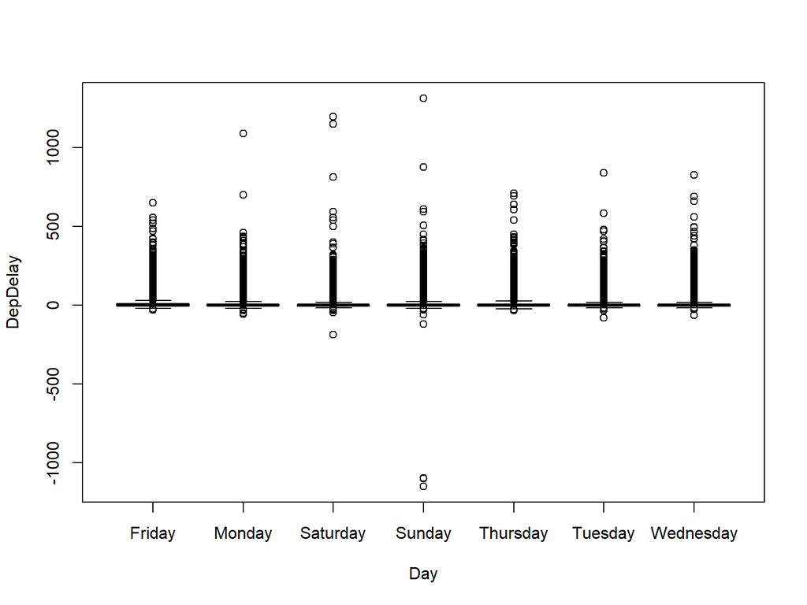

```r
boxplot(DepDelay~Day, o)
```

## Question 1

### What is the best time of day, day of the week and time of year to fly to minimise delays?

To answer this question, we will break it into 3 parts. Firstly, what is the best time of the day to fly?

Since we are dealing with time, we must first convert the time variables into a *time* class. We will then bin the variable `CRSDepTime` into time intervals of one hour. We use the `CRSDepTime` variable here instead of `DepTime` because we want the *Scheduled Departure* times instead of the *Actual Departure* times. This is because the scheduled departure time is known, but the actual departure time will always be unknown.

For clarity, I will explain what the time classes mean.  
`0` represents scheduled departure times from 12am to 1am.  
`1` represents scheduled departure times from 1am to 2am.  
and so on and so forth.

```r
#Create copy of sample to keep the integrity of original sample
o2 <- o

#Changing integer values of time-based variables to time format
o2[5:8] <- o2[5:8]%>%
  lapply(sprintf, fmt="%04d")%>%
  lapply(strptime, format= "%H%M")%>%
  lapply(as.POSIXct, format= "%H:%M")

#Making a graph to determine best time to fly
classes <- cut(as.POSIXlt(o2$CRSDepTime)$hour, breaks=c(0:24),
               c("0","1","2","3","4","5","6","7","8","9","10","11","12","13","14","15","16","17","18","19","20","21","22","23"),
               right=F, include.lowest = T)
```

We will now create a subset of the sample as we want only the relevant variables. We will opt to find the average for both `DepDelay` and `ArrDelay` because we want to know what the typical value is for each hour.

```r
DelayTimes <-data.frame(timeclass=classes,
                    o2$DepDelay,
                    o2$ArrDelay)


avg_time_delay <- DelayTimes %>%
  group_by(timeclass)%>%
  summarise(ArrDelay=mean(o2.ArrDelay, na.rm=T),
            DepDelay=mean(o2.DepDelay, na.rm=T),
            NumOfFlights=n())%>%
  arrange(timeclass)

#Normalize by log transformation
avg_time_delay$logFlights <- log(avg_time_delay$NumOfFlights)
avg_time_delay
```

```
## # A tibble: 24 x 5
##    timeclass ArrDelay DepDelay NumOfFlights logFlights
##    <fct>        <dbl>    <dbl>        <int>      <dbl>
##  1 0            1.94     4.45           312      5.74
##  2 1            1.94     3.14           159      5.07
##  3 2            3.69     0.655           30      3.40
##  4 3            1       -2.5              2      0.693
##  5 4           -1        8                2      0.693
##  6 5           -2.10     1.06          1721      7.45
##  7 6           -0.510    0.932        12542      9.44
##  8 7            0.414    2.02         13467      9.51
##  9 8            1.59     3.12         14320      9.57
## 10 9            2.37     3.71         13876      9.54
## # ... with 14 more rows
```

## What is the best time of the day to fly?

The graphs below show that **5am to 7am** is the best time of the day to fly because the average delay during these hours is less than or around 5 minutes. Past 7am is when the average Arrival delay starts to noticeably and steadily increase. This is probably due to the increase of delays in other airports.

Arguably, **1am to 3am** is also a contender, but the second graph shows that not a lot of flights occur during these hours, understandably due to lack of working staff as it is during the night.

```r
melttime <- melt(avg_time_delay[1:3])
```

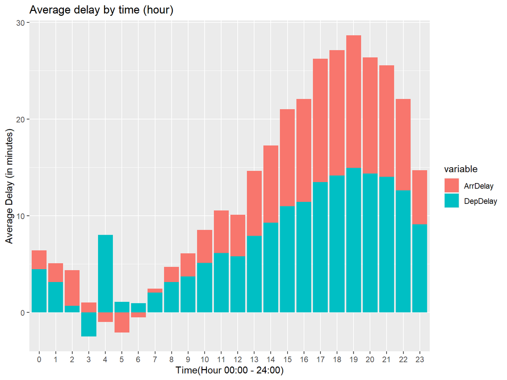

```r
time_bar_plot <- ggplot(melttime, mapping= aes(x=timeclass, y=value, fill=variable))+
  geom_bar(stat="identity", position=position_stack())+
  ggtitle("Average delay by time (hour)")+
  xlab("Time(Hour 00:00 - 24:00)")+ylab("Average Delay (in minutes)")


time_scatter_plot <- ggplot(avg_time_delay, aes(x=logFlights, y=DepDelay))+
  geom_point(size=2)+
  geom_text(hjust=-.2, vjust=0,label=avg_time_delay$timeclass)+
  ylab("Average Departure Delay (in minutes)")

time_bar_plot
```

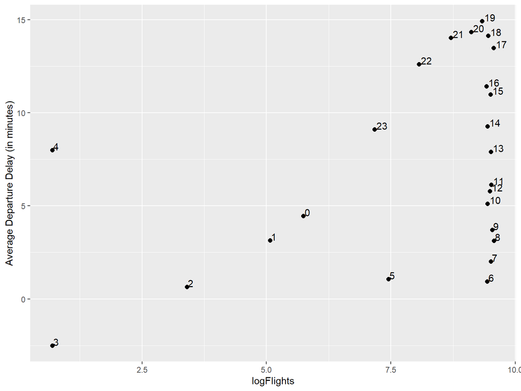

```r
time_scatter_plot
```

## What is the best day of the week to fly?

Similar to the above, I will create a subset of the sample.

```r
#Finding the average and sum delay for each day
avg_daily_delay <- o2 %>%
  group_by(Day)%>%
  summarize(DepDelay=mean(DepDelay, na.rm=T),
            ArrDelay=mean(ArrDelay, na.rm=T),
            NumOfFlights=n())%>%
  arrange(DepDelay)

avg_daily_delay
```

```
## # A tibble: 7 x 4
##   Day       DepDelay ArrDelay NumOfFlights
##   <fct>        <dbl>    <dbl>        <int>
## 1 Saturday      5.93     2.85        26255
## 2 Tuesday       6.55     5.15        29825
## 3 Wednesday     7.91     7.06        29947
## 4 Sunday        8.42     6.55        28540
## 5 Monday        8.78     7.41        30145
## 6 Thursday      9.50     8.89        30355
## 7 Friday        9.84     8.75        30419
```

Based on the graphs below, the best day to fly is **Saturday** or **Tuesday**. Keep in mind that the least number of flights occur on **Saturday** which explains why it has the lowest average delay. **Tuesday** has more or less the same number of flights as the other days, but has the lowest average delay despite being as busy.

The second graph demonstrates that `DepDelay` and `ArrDelay` share a relationship as their respective lines are very similar to each other. This suggests that departure delay causes arrival delay. For flights that have departure delay but no or less arrival delay, it could be speculated that the plane adjusted its speed to match its scheduled arrival time.

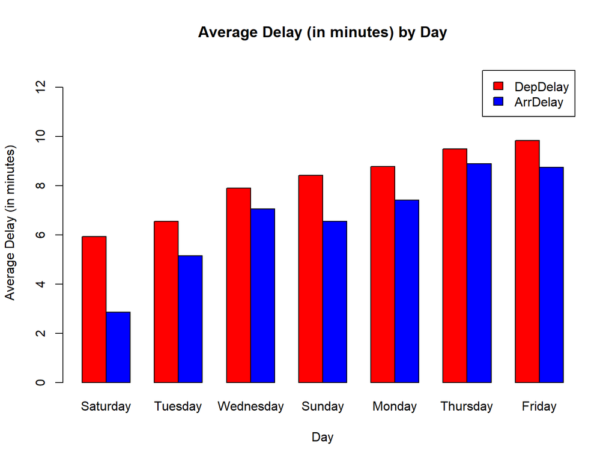

```r
daily_bar_plot <- barplot(t(as.matrix(avg_daily_delay[, 2:3])),
        beside=T,
        names.arg=avg_daily_delay$Day,
        legend.text=T,
        col=c("red","blue"),
        main="Average Delay (in minutes) by Day",
        ylim=c(0,13),
        ylab="Average Delay (in minutes)",
        xlab="Day")
```

```r
meltday <- melt(avg_daily_delay[1:3])
```

```r
meltday[4] <- avg_daily_delay[4]
daily_line_plot <- ggplot(meltday, aes(x=NumOfFlights, y=value, color=variable))+
  geom_line(size=2)+
  geom_text(hjust=-.1, vjust=0,label=meltday$Day)+
  xlab("Flights")+ylab("Average delay (in minutes)")

daily_bar_plot
```

```
##      [,1] [,2] [,3] [,4] [,5] [,6] [,7]
## [1,]  1.5  4.5  7.5 10.5 13.5 16.5 19.5
## [2,]  2.5  5.5  8.5 11.5 14.5 17.5 20.5
```

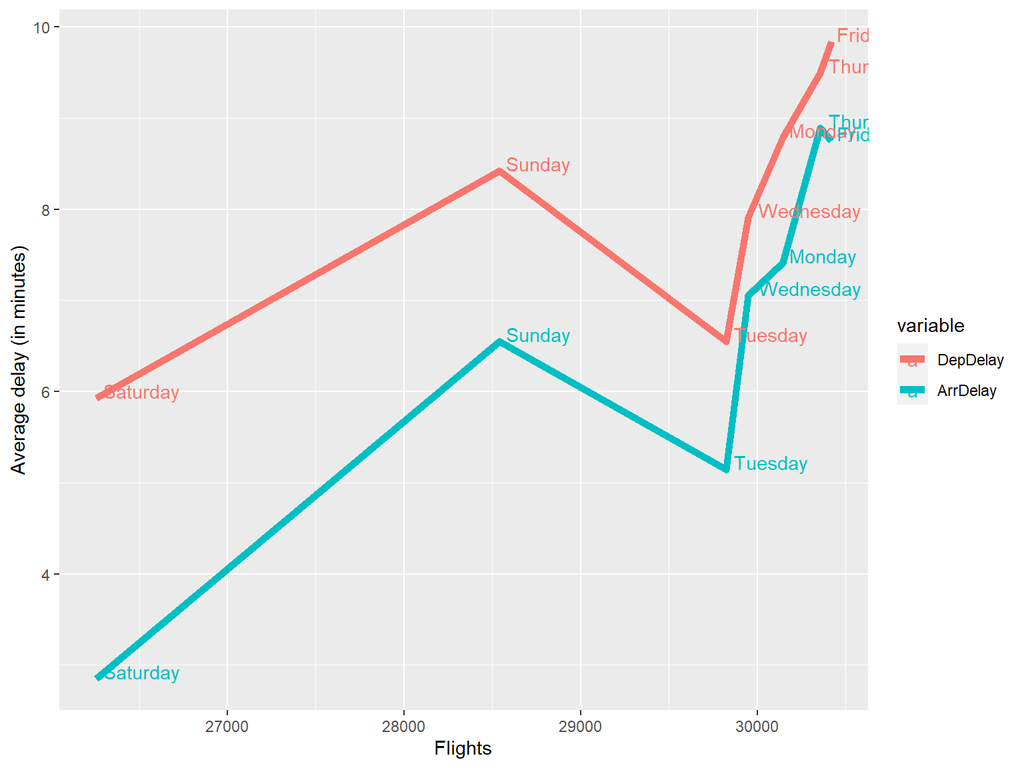

```r
daily_line_plot
```

## What is the best time of the year to fly?

For better clarity of our tables and plots, we will add a new variable `NameOfMonth`. We use `FlightDate` here instead of `Month` because the former is a *date* class. Because of this, R will be able to convert the month integer extracted from the date to the actual name of the month. If we use the latter which is an *integer* class, R will not be able to convert it because it is just a number.

```r
#Adding name of Month to sample
o2$NameOfMonth <- as.factor(months(o2$FlightDate))

avg_monthly_delay <- o2 %>%
  group_by(NameOfMonth)%>%
  summarize(DepDelay=mean(DepDelay,na.rm=T),
            ArrDelay=mean(ArrDelay, na.rm=T),
            NumOfFlights=n())%>%
  arrange(DepDelay)

avg_monthly_delay
```

```
## # A tibble: 12 x 4
##    NameOfMonth DepDelay ArrDelay NumOfFlights
##    <fct>          <dbl>    <dbl>        <int>
##  1 September       4.77     1.93        16696
##  2 April           4.78     2.54        16955
##  3 October         6.20     4.42        17319
##  4 May             6.64     5.20        17413
##  5 February        7.13     5.86        15828
##  6 November        7.28     5.47        16571
##  7 March           7.77     6.04        17553
##  8 August          9.00     8.07        18059
##  9 January         9.21     8.49        16975
## 10 June           11.3     10.9         17251
## 11 December       11.7     10.6         16979
## 12 July           12.0     11.1         17887
```

The graphs below show that **September** or **April** is the best time of the year to fly. The second graph shows the number of flights that occur for each month and the average delay for each month. Again, we see that there is a correlation between `DepDelay` and `ArrDelay`. Unlike the graphs using `Day` as the x-axis, we also see that there is no relationship between the number of flights and the average delay.

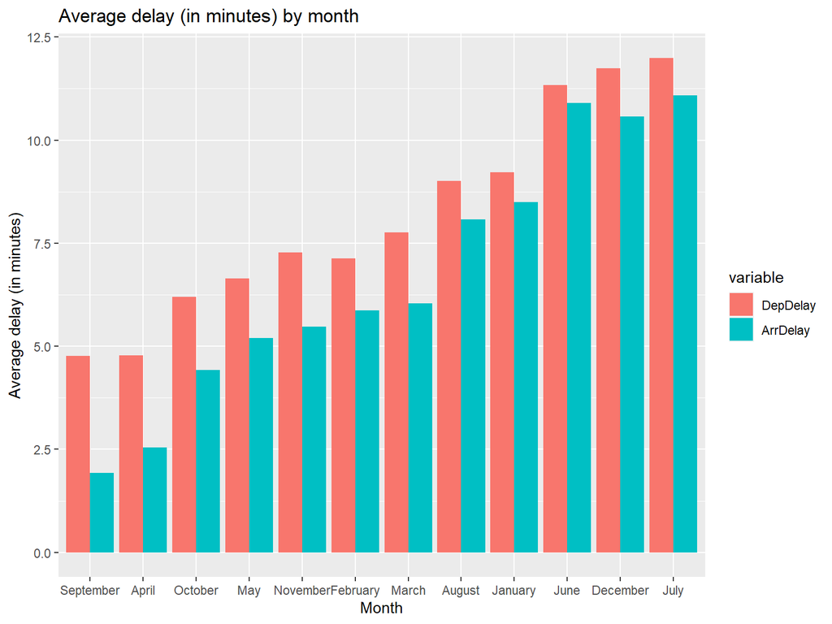

```r
#Plot results for visualization
meltmonth <- melt(avg_monthly_delay[1:3])
month_bar_plot <- ggplot(meltmonth, aes(x=reorder(NameOfMonth, +value), y=value, fill=variable))+
  geom_bar(stat = "identity", position = 'dodge')+
  xlab("Month")+ylab("Average delay (in minutes)")+
  ggtitle("Average delay (in minutes) by month")

meltmonth[4] <- avg_monthly_delay[4]
month_line_plot <- ggplot(meltmonth, aes(x=NumOfFlights, y=value, color=variable))+
  geom_line()+
  geom_point()+
  geom_text(hjust=-.15, vjust=0,label=meltmonth$NameOfMonth)+
  xlab("Flights")+ylab("Average delay (in minutes)")

month_bar_plot
```

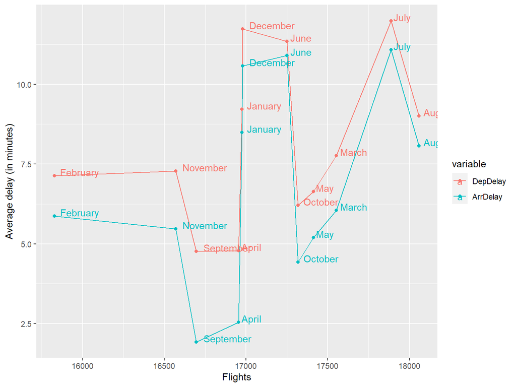

```r
month_line_plot
```

## Question 2

### Do older planes suffer more delays?

This question requires the planes table to answer. Before we start, we must clean the planes table by dropping rows with invalid/empty issue date. Then we will need to convert the `issue_date` variable in the table to a *date* class, so that we can properly extract the year when sub-setting later.

```r
#Clean up 'planes' table by dropping rows with invalid/empty issue date
planes2 <- planes%>%
  filter(issue_date!="None",
         issue_date!="")
class(planes2$issue_date)
```

```
## [1] "character"
```

```r
planes2$issue_date <- as.Date(planes2$issue_date, format="%m/%d/%Y")
class(planes2$issue_date)
```

```
## [1] "Date"
```

Next, we will subset the sample with relevant variables and values. This time we are required to join the `ontime` and `planes` table to obtain the relevant variables from both tables.

Oddly enough, there are certain models that have an issue date beyond 2005. We can assume that this is not an error, but rather that the planes are being used for a different purpose. We are only interested in planes with an issue date equal to or less than 2005 however, so these will be dropped.

We can also log transform the number of flights like we did before as the variable in the `q2` table has a large variation, but the plot output does not offer better clarity and looks more clustered, so we will opt not to transform.

```r
#Subset
q2 <- o2 %>%
  inner_join(planes2, by=c("TailNum"="tailnum"))%>%
  mutate(YearIssued=format(issue_date, "%Y"))%>%
  group_by(YearIssued)%>%
  summarise(DepDelay=mean(DepDelay, na.rm=T),
            ArrDelay=mean(ArrDelay, na.rm=T),
            Flights=n())
q2 <- subset(q2, YearIssued<=2005)

q2
```

```
## # A tibble: 25 x 4
##    YearIssued DepDelay ArrDelay Flights
##    <chr>         <dbl>    <dbl>   <int>
##  1 1976           1.41    -1.49      59
##  2 1977           8.95     4.62      37
##  3 1978           4.87     2.96      46
##  4 1984           9.25     7.21      89
##  5 1985           9.00     7.41    1348
##  6 1986           6.60     6.90    2639
##  7 1987           8.91     8.31    1884
##  8 1988           9.07     8.77    2676
##  9 1989           9.13     8.39    3157
## 10 1990           9.14     8.17    2580
## # ... with 15 more rows
```

Going by a ratio measurement of flight:delay, **we can safely say that older planes do suffer more delays**. The only exception is planes issued in 2005: they fly the least in the 1998-2005 group, yet have a higher average delay.

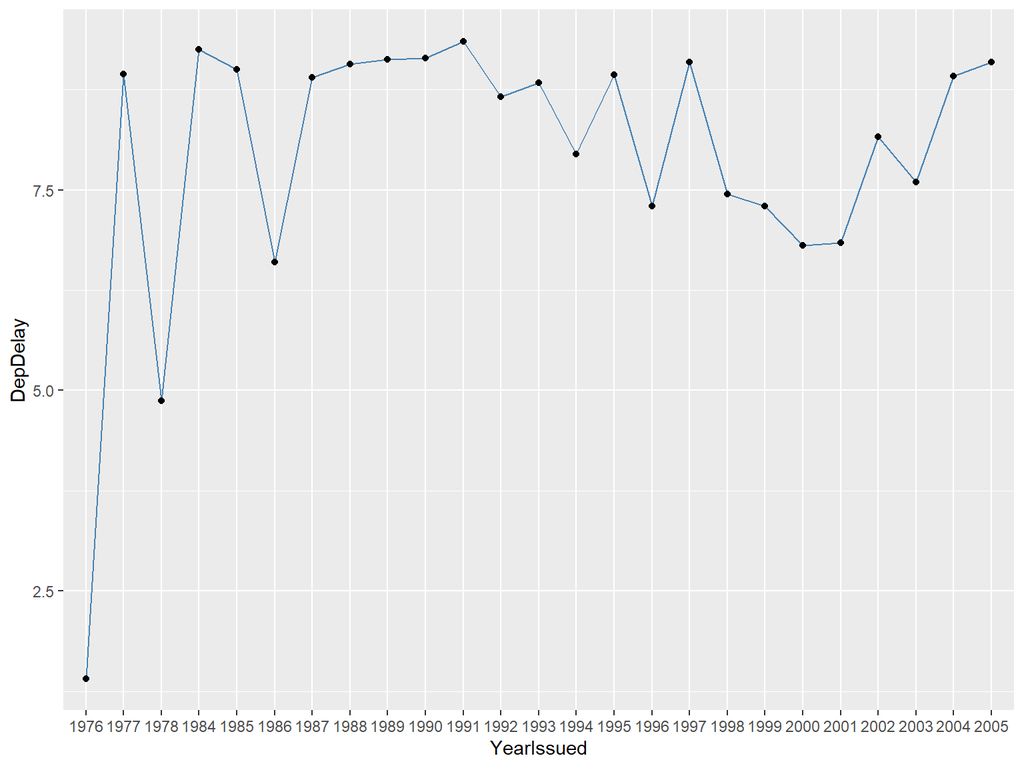

```r
#Plot for visual
plane_line_plot <- ggplot(q2, aes(x=YearIssued, y=DepDelay, group=1))+
  geom_line(color="steelblue")+
  geom_point()

plane_bar_plot <- ggplot(q2, aes(x=YearIssued, y=Flights))+
  geom_bar(stat="identity", position=position_stack(), fill="steelblue")


q2<-q2[c(-3)]
plane_plot <- ggplot(q2, aes(x=Flights, y=DepDelay))+
  geom_line(col="steelblue")+
  geom_point()+
  geom_text(hjust=-.12, vjust=-.1,label=q2$YearIssued)

plane_line_plot
```

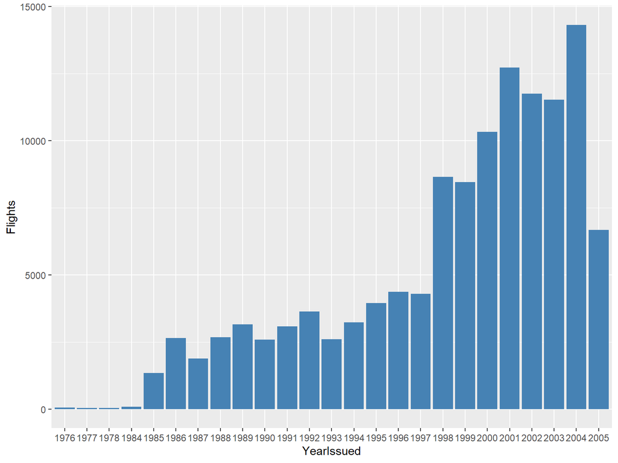

```r
plane_bar_plot
```

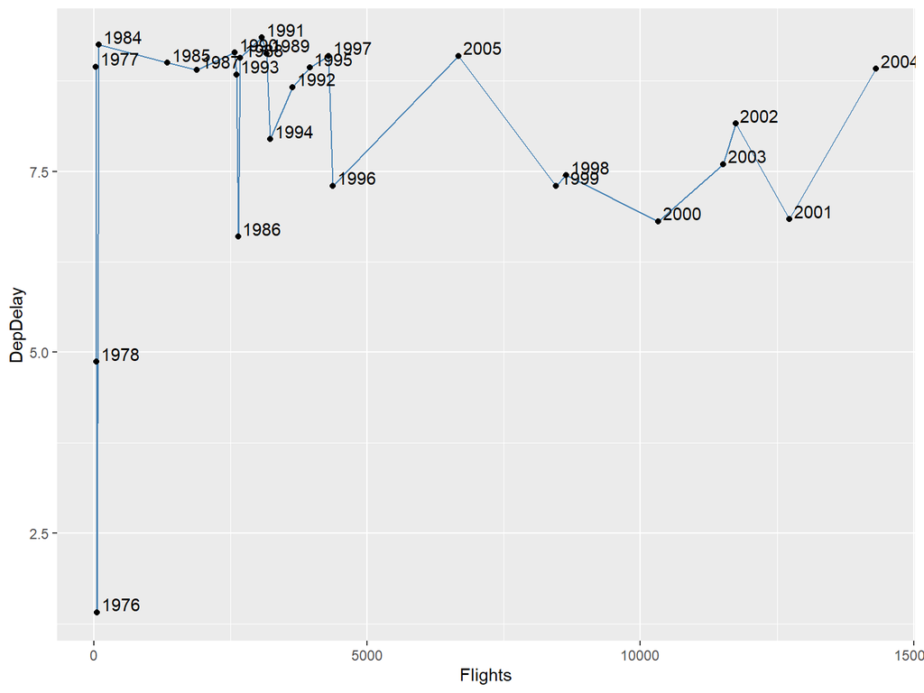

```r
plane_plot
```

## Question 3

### How does the number of people flying between different locations change over time?

Before we begin, we will drop flights that were cancelled or diverted due to their association with NA values and also because we can treat these flights as if they never flew. We are only interested in flights that have filled out the variables `DepTime` and `ArrTime` because this would mean that the flights have flown and reached their destinations.

To answer this question, we must figure out the number of flights that happen for each month in their respective years. This requires grouping the rows, but we are unable to do this unless we remove the day of the month in the date. However, by removing the day in the date, R will not recognise the month/year date as a *date* class because it is incomplete. We will substitute the 1st day of the month instead to resolve this.

```r
#Create another copy of sample
o3 <- o2

#Removing cancelled and diverted flights from the table due to association with NA values
o3 <- subset(o3, Cancelled==0 & Diverted==0)
#Subset again by removing Cancelled and Diverted variables
o3 <- o3[c(-17:-19)]

#Subset by filtering
q3 <- o3 %>%
  mutate(Date=format(FlightDate, "%Y/%m"))%>%
  group_by(Date)%>%
  summarise(Flights=n())%>%
  arrange(Date)

q3$Date <- as.Date(paste(q3$Date,"/01", sep=""), format="%Y/%m/%d")
class(q3$Date)
```

```
## [1] "Date"
```

```r
q3
```

```
## # A tibble: 24 x 2
##    Date       Flights
##    <date>       <int>
##  1 2004-01-01    8287
##  2 2004-02-01    7784
##  3 2004-03-01    8496
##  4 2004-04-01    8301
##  5 2004-05-01    8322
##  6 2004-06-01    8356
##  7 2004-07-01    8665
##  8 2004-08-01    8831
##  9 2004-09-01    8230
## 10 2004-10-01    8800
## # ... with 14 more rows
```

In the graph below, people tend to fly less near the end of or beginning of the year (Nov-Feb). There are also certain months where the number of people flying dips, creating valleys in the graph. This phenomenon occurs in February, September and November, and this remains consistent in both years. Similarly, there are months where the number of people flying peaks, and this happens in March, August and October.

It also appears that in 2004, people flew more in October to December, but in 2005 less people flew in those months. People also flew less in May to June of 2004, but more people flew in May to August of 2005.

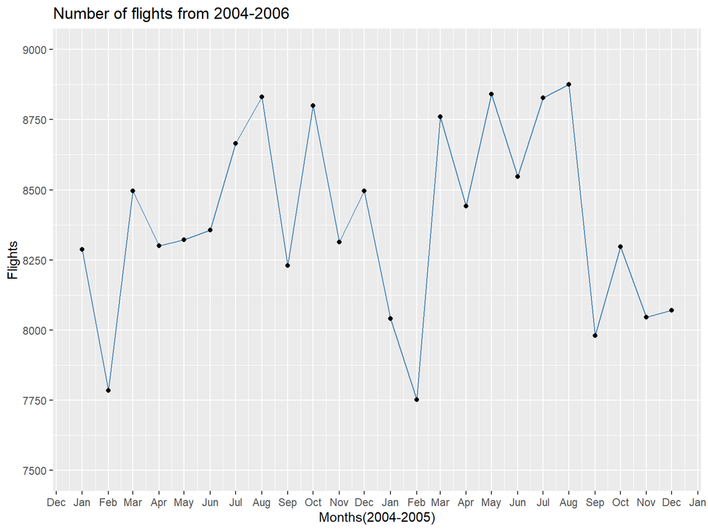

```r
#Plot for visualisation of data
#Limit time frame
ggplot(q3, aes(x=Date, y=Flights))+
  geom_line(color="steelblue")+
  geom_point()+
  scale_x_date(date_breaks = "1 month", date_labels="%b")+
  scale_y_continuous(breaks=seq(7500,9000,250),limits=c(7500,9000))+
  ggtitle("Number of flights from 2004-2006")+
  xlab("Months(2004-2005)")
```

## Question 4

### Can you detect cascading failures as delays in one airport create delays in others?

We subset and filter rows with positive `LateAircraftDelay` values because presumably this variable explains delays in the airport.

```r
#Subset and transform for readability
o4 <- o

#Subset rows with positive LateAircraftDelay values
o4 <- subset(o4, LateAircraftDelay > 0)
```

ORD and ATL are the two airports with the highest amount of late aircraft delays. Other notable airports are DFW, EWR, LAS, PHL, IAD, LGA, DEN, LAX, PHX and MDW. If we look at the airports individually, notice that most of the top 9 airports that cause the highest delays are in the top 12 airports of the `mostdelay` table.

From this, we can assume that yes, delays in one airport cause delays in others.

```r
#Query and explore data to find connections
mostdelays <- o4%>%
  inner_join(airports, by=c("Origin"="iata"))%>%
  group_by(Origin, airport)%>%
  summarise(SumDelay=sum(LateAircraftDelay), Flights=n())%>%
  filter(Flights>=30)%>%
  arrange(desc(SumDelay))
ORDdelays <- o4%>%
  group_by(Dest, Origin)%>%
  summarise(SumDelay=sum(LateAircraftDelay), Flights=n())%>%
  filter(Dest=="ORD")%>%
  arrange(desc(SumDelay))%>%
  top_n(9)
EWRdelays <- o4%>%
  group_by(Dest, Origin)%>%
  summarise(SumDelay=sum(LateAircraftDelay), Flights=n())%>%
  filter(Dest=="EWR")%>%
  arrange(desc(SumDelay))%>%
  top_n(9)
MSPdelays <- o4%>%
  group_by(Dest, Origin)%>%
  summarise(SumDelay=sum(LateAircraftDelay), Flights=n())%>%
  filter(Dest=="MSP")%>%
  arrange(desc(SumDelay))%>%
  top_n(9)
RDUdelays <- o4%>%
  group_by(Dest, Origin)%>%
  summarise(SumDelay=sum(LateAircraftDelay), Flights=n())%>%
  filter(Dest=="RDU")%>%
  arrange(desc(SumDelay))%>%
  top_n(9)
mostdelays
```

```
## # A tibble: 84 x 4
## # Groups:   Origin [84]
##    Origin airport                           SumDelay Flights
##    <chr>  <chr>                                <int>   <int>
##  1 ORD    Chicago O'Hare International         66242    1399
##  2 ATL    William B Hartsfield-Atlanta Intl    54572    1157
##  3 DFW    Dallas-Fort Worth International      29966     843
##  4 EWR    Newark Intl                          26699     494
##  5 LAS    McCarran International               25113     659
##  6 PHL    Philadelphia Intl                    21930     459
##  7 IAD    Washington Dulles International      19900     361
##  8 DEN    Denver Intl                          15965     392
##  9 LAX    Los Angeles International            15595     452
## 10 LGA    LaGuardia                            14596     336
## # ... with 74 more rows
```

```r
ORDdelays
```

```
## # A tibble: 9 x 4
## # Groups:   Dest [1]
##   Dest  Origin SumDelay Flights
##   <chr> <chr>     <int>   <int>
## 1 ORD   ATL        1857      36
## 2 ORD   LGA        1836      35
## 3 ORD   EWR        1693      22
## 4 ORD   IAD        1407      28
## 5 ORD   PHL        1369      33
## 6 ORD   DEN         952      23
## 7 ORD   DSM         901      21
## 8 ORD   PIT         789      22
## 9 ORD   MIA         738      20
```

```r
EWRdelays
```

```
## # A tibble: 11 x 4
## # Groups:   Dest [1]
##    Dest  Origin SumDelay Flights
##    <chr> <chr>     <int>   <int>
##  1 EWR   ORD        1567      35
##  2 EWR   IAD        1511      24
##  3 EWR   ATL         989      29
##  4 EWR   RDU         798      20
##  5 EWR   CLT         792      20
##  6 EWR   MCO         619      10
##  7 EWR   DTW         450      12
##  8 EWR   FLL         376      11
##  9 EWR   SFO         370       9
## 10 EWR   BOS         356       9
## 11 EWR   SJU         231       9
```

```r
MSPdelays
```

```
## # A tibble: 10 x 4
## # Groups:   Dest [1]
##    Dest  Origin SumDelay Flights
##    <chr> <chr>     <int>   <int>
##  1 MSP   ORD        1961      47
##  2 MSP   DEN        1112      17
##  3 MSP   ATL         924      23
##  4 MSP   EWR         565      14
##  5 MSP   MDW         458      10
##  6 MSP   OMA         367       9
##  7 MSP   DFW         322      12
##  8 MSP   PHX         318       9
##  9 MSP   LGA         293       9
## 10 MSP   DCA         217       9
```

```r
RDUdelays
```

```
## # A tibble: 9 x 4
## # Groups:   Dest [1]
##   Dest  Origin SumDelay Flights
##   <chr> <chr>     <int>   <int>
## 1 RDU   ATL        1312      26
## 2 RDU   PHL         812      23
## 3 RDU   EWR         715      15
## 4 RDU   LGA         526      15
## 5 RDU   ORD         525      10
## 6 RDU   BWI         315       9
## 7 RDU   BOS         291       8
## 8 RDU   DCA         222       8
## 9 RDU   DTW         210      10
```

We will make a map plot to visualise the connections between airports. To avoid a cluster of lines we will only filter and show airports with a total late aircraft delay above or equal to 1,500 minutes.

```r
mostdelays2 <- o4%>%
  inner_join(airports, by=c("Origin"="iata"))%>%
  group_by(Origin, lat, long, Dest)%>%
  summarise(SumDelay=sum(LateAircraftDelay), Flights=n())%>%
  rename(olat=lat, olong=long)%>%
  filter(SumDelay>=1500)%>%
  arrange(desc(SumDelay))
mostdelays3<- o4%>%
  inner_join(airports, by=c("Dest"="iata"))%>%
  group_by(Origin, Dest, lat, long)%>%
  summarise(SumDelay=sum(LateAircraftDelay), Flights=n())%>%
  rename(dlat=lat, dlong=long)%>%
  filter(SumDelay>=1500)%>%
  arrange(desc(SumDelay))
```

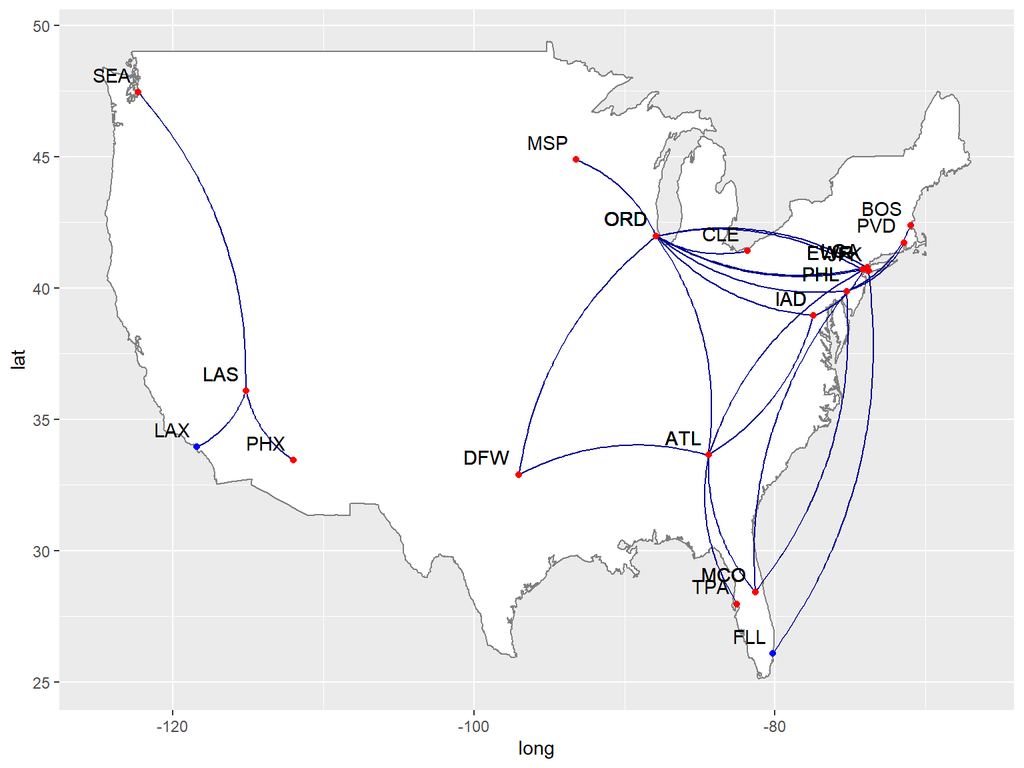

```r
mostdelays3[7:8]<-mostdelays2[2:3]


map <- borders("usa", fill='white')

ggplot() + map +
  geom_curve(mostdelays3,
             mapping=aes(x=olong, y=olat, xend=dlong, yend=dlat),
             col="#00008b",
             size=.5,
             curvature=.2)+
  geom_point(mostdelays3,
             mapping=aes(x=olong, y=olat),
             color="blue",
             size=1.5)+
  geom_point(mostdelays3,
             mapping=aes(x=dlong, y=dlat),
             color="red")+
  geom_text(mostdelays3, mapping=aes(x=olong, y=olat, label=Origin), hjust=1.2, vjust=-.7)+
  geom_text(mostdelays3, mapping=aes(x=dlong, y=dlat, label=Dest), hjust=1.2, vjust=-.7)
```

## Question 5

### Use the available variables to construct a model that predicts delays.

First, it must be said that for this question, I will not focus on the accuracy of the model, but rather on the process of making the models.

We will utilize the `caret` package for the models.

We need to create 2 separate tables; one without `DepDelay` and one without `ArrDelay`. This is because: 1. Both variables are strongly correlated and `ArrDelay` depends heavily on `DepDelay`. Using both would give us a high $R^{2}$ value and better predictive power in our models, but realistically this would not be possible because… 2. Both variables are also unknown variables, meaning that you would not know in advance what the `DepDelay` or `ArrDelay` is.

We also want to include Origin and Dest, however these variables are categorical and due to the nature of the sample (it is quite large), it is impossible to bin these without long processing times and a large memory. We can simply use the Distance variable as a substitute, though we must keep in mind that some airport connections share the same distance.

```r
library(skimr)
library(caret)
o5<-o[c(2:19)]
skim(o5)
```

Data summary

| Name | o5 |
| --- | --- |
| Number of rows | 205486 |
| Number of columns | 18 |
| _______________________ |  |
| Column type frequency: |  |
| character | 5 |
| numeric | 12 |
| ________________________ |  |
| Group variables | Month |

**Variable type: character**

| skim_variable | Month | n_missing | complete_rate | min | max | empty | n_unique | whitespace |
| --- | --- | --- | --- | --- | --- | --- | --- | --- |
| UniqueCarrier | 1 | 0 | 1 | 2 | 2 | 0 | 19 | 0 |
| UniqueCarrier | 2 | 0 | 1 | 2 | 2 | 0 | 19 | 0 |
| UniqueCarrier | 3 | 0 | 1 | 2 | 2 | 0 | 19 | 0 |
| UniqueCarrier | 4 | 0 | 1 | 2 | 2 | 0 | 19 | 0 |
| UniqueCarrier | 5 | 0 | 1 | 2 | 2 | 0 | 20 | 0 |
| UniqueCarrier | 6 | 0 | 1 | 2 | 2 | 0 | 20 | 0 |
| UniqueCarrier | 7 | 0 | 1 | 2 | 2 | 0 | 20 | 0 |
| UniqueCarrier | 8 | 0 | 1 | 2 | 2 | 0 | 20 | 0 |
| UniqueCarrier | 9 | 0 | 1 | 2 | 2 | 0 | 20 | 0 |
| UniqueCarrier | 10 | 0 | 1 | 2 | 2 | 0 | 20 | 0 |
| UniqueCarrier | 11 | 0 | 1 | 2 | 2 | 0 | 20 | 0 |
| UniqueCarrier | 12 | 0 | 1 | 2 | 2 | 0 | 20 | 0 |
| TailNum | 1 | 0 | 1 | 0 | 6 | 2 | 4795 | 0 |
| TailNum | 2 | 0 | 1 | 1 | 6 | 0 | 4720 | 0 |
| TailNum | 3 | 0 | 1 | 1 | 6 | 0 | 4667 | 0 |
| TailNum | 4 | 0 | 1 | 1 | 6 | 0 | 4676 | 0 |
| TailNum | 5 | 0 | 1 | 1 | 6 | 0 | 4750 | 0 |
| TailNum | 6 | 0 | 1 | 1 | 6 | 0 | 4740 | 0 |
| TailNum | 7 | 0 | 1 | 1 | 6 | 0 | 4616 | 0 |
| TailNum | 8 | 0 | 1 | 1 | 6 | 0 | 4585 | 0 |
| TailNum | 9 | 0 | 1 | 1 | 6 | 0 | 4483 | 0 |
| TailNum | 10 | 0 | 1 | 1 | 6 | 0 | 4505 | 0 |
| TailNum | 11 | 0 | 1 | 1 | 6 | 0 | 4495 | 0 |
| TailNum | 12 | 0 | 1 | 1 | 6 | 0 | 4503 | 0 |
| Origin | 1 | 0 | 1 | 3 | 3 | 0 | 265 | 0 |
| Origin | 2 | 0 | 1 | 3 | 3 | 0 | 267 | 0 |
| Origin | 3 | 0 | 1 | 3 | 3 | 0 | 265 | 0 |
| Origin | 4 | 0 | 1 | 3 | 3 | 0 | 262 | 0 |
| Origin | 5 | 0 | 1 | 3 | 3 | 0 | 262 | 0 |
| Origin | 6 | 0 | 1 | 3 | 3 | 0 | 267 | 0 |
| Origin | 7 | 0 | 1 | 3 | 3 | 0 | 271 | 0 |
| Origin | 8 | 0 | 1 | 3 | 3 | 0 | 272 | 0 |
| Origin | 9 | 0 | 1 | 3 | 3 | 0 | 263 | 0 |
| Origin | 10 | 0 | 1 | 3 | 3 | 0 | 266 | 0 |
| Origin | 11 | 0 | 1 | 3 | 3 | 0 | 259 | 0 |
| Origin | 12 | 0 | 1 | 3 | 3 | 0 | 268 | 0 |
| Dest | 1 | 0 | 1 | 3 | 3 | 0 | 263 | 0 |
| Dest | 2 | 0 | 1 | 3 | 3 | 0 | 262 | 0 |
| Dest | 3 | 0 | 1 | 3 | 3 | 0 | 271 | 0 |
| Dest | 4 | 0 | 1 | 3 | 3 | 0 | 261 | 0 |
| Dest | 5 | 0 | 1 | 3 | 3 | 0 | 265 | 0 |
| Dest | 6 | 0 | 1 | 3 | 3 | 0 | 268 | 0 |
| Dest | 7 | 0 | 1 | 3 | 3 | 0 | 274 | 0 |
| Dest | 8 | 0 | 1 | 3 | 3 | 0 | 270 | 0 |
| Dest | 9 | 0 | 1 | 3 | 3 | 0 | 265 | 0 |
| Dest | 10 | 0 | 1 | 3 | 3 | 0 | 266 | 0 |
| Dest | 11 | 0 | 1 | 3 | 3 | 0 | 265 | 0 |
| Dest | 12 | 0 | 1 | 3 | 3 | 0 | 264 | 0 |
| CancellationCode | 1 | 0 | 1 | 0 | 1 | 16367 | 4 | 0 |
| CancellationCode | 2 | 0 | 1 | 0 | 1 | 15558 | 4 | 0 |
| CancellationCode | 3 | 0 | 1 | 0 | 1 | 17284 | 4 | 0 |
| CancellationCode | 4 | 0 | 1 | 0 | 1 | 16763 | 4 | 0 |
| CancellationCode | 5 | 0 | 1 | 0 | 1 | 17203 | 4 | 0 |
| CancellationCode | 6 | 0 | 1 | 0 | 1 | 16952 | 4 | 0 |
| CancellationCode | 7 | 0 | 1 | 0 | 1 | 17538 | 4 | 0 |
| CancellationCode | 8 | 0 | 1 | 0 | 1 | 17753 | 4 | 0 |
| CancellationCode | 9 | 0 | 1 | 0 | 1 | 16231 | 5 | 0 |
| CancellationCode | 10 | 0 | 1 | 0 | 1 | 17112 | 4 | 0 |
| CancellationCode | 11 | 0 | 1 | 0 | 1 | 16387 | 4 | 0 |
| CancellationCode | 12 | 0 | 1 | 0 | 1 | 16598 | 4 | 0 |

**Variable type: numeric**

| skim_variable | Month | n_missing | complete_rate | mean | sd | p0 | p25 | p50 | p75 | p100 | hist |
| --- | --- | --- | --- | --- | --- | --- | --- | --- | --- | --- | --- |
| DayofMonth | 1 | 0 | 1.00 | 16.15 | 9.01 | 1 | 8.00 | 16.0 | 24.00 | 31 | ▇▆▇▇▇ |
| DayofMonth | 2 | 0 | 1.00 | 14.79 | 8.25 | 1 | 8.00 | 15.0 | 22.00 | 29 | ▇▇▆▇▇ |
| DayofMonth | 3 | 0 | 1.00 | 16.02 | 8.96 | 1 | 8.00 | 16.0 | 24.00 | 31 | ▇▇▇▇▇ |
| DayofMonth | 4 | 0 | 1.00 | 15.41 | 8.62 | 1 | 8.00 | 15.0 | 23.00 | 30 | ▇▇▇▇▇ |
| DayofMonth | 5 | 0 | 1.00 | 15.98 | 8.93 | 1 | 8.00 | 16.0 | 24.00 | 31 | ▇▇▇▇▇ |
| DayofMonth | 6 | 0 | 1.00 | 15.49 | 8.63 | 1 | 8.00 | 16.0 | 23.00 | 30 | ▇▇▇▇▇ |
| DayofMonth | 7 | 0 | 1.00 | 16.06 | 8.90 | 1 | 8.00 | 16.0 | 24.00 | 31 | ▇▇▇▇▇ |
| DayofMonth | 8 | 0 | 1.00 | 15.94 | 8.96 | 1 | 8.00 | 16.0 | 24.00 | 31 | ▇▇▇▇▇ |
| DayofMonth | 9 | 0 | 1.00 | 15.50 | 8.66 | 1 | 8.00 | 16.0 | 23.00 | 30 | ▇▇▇▇▇ |
| DayofMonth | 10 | 0 | 1.00 | 15.98 | 8.89 | 1 | 8.00 | 16.0 | 24.00 | 31 | ▇▇▇▇▇ |
| DayofMonth | 11 | 0 | 1.00 | 15.34 | 8.63 | 1 | 8.00 | 15.0 | 23.00 | 30 | ▇▇▇▇▇ |
| DayofMonth | 12 | 0 | 1.00 | 16.03 | 8.92 | 1 | 8.00 | 16.0 | 24.00 | 31 | ▇▇▇▇▇ |
| DayOfWeek | 1 | 0 | 1.00 | 4.02 | 2.01 | 1 | 2.00 | 4.0 | 6.00 | 7 | ▇▃▅▅▇ |
| DayOfWeek | 2 | 0 | 1.00 | 3.99 | 2.01 | 1 | 2.00 | 4.0 | 6.00 | 7 | ▇▃▅▅▇ |
| DayOfWeek | 3 | 0 | 1.00 | 3.80 | 1.96 | 1 | 2.00 | 4.0 | 5.00 | 7 | ▇▅▃▃▆ |
| DayOfWeek | 4 | 0 | 1.00 | 4.01 | 1.95 | 1 | 2.00 | 4.0 | 6.00 | 7 | ▇▅▅▅▇ |
| DayOfWeek | 5 | 0 | 1.00 | 3.93 | 2.07 | 1 | 2.00 | 4.0 | 6.00 | 7 | ▇▃▃▃▇ |
| DayOfWeek | 6 | 0 | 1.00 | 3.89 | 1.95 | 1 | 2.00 | 4.0 | 6.00 | 7 | ▇▅▅▃▇ |
| DayOfWeek | 7 | 0 | 1.00 | 4.09 | 1.96 | 1 | 2.00 | 4.0 | 6.00 | 7 | ▇▃▅▅▇ |
| DayOfWeek | 8 | 0 | 1.00 | 3.82 | 2.03 | 1 | 2.00 | 4.0 | 6.00 | 7 | ▇▃▃▃▆ |
| DayOfWeek | 9 | 0 | 1.00 | 3.93 | 1.92 | 1 | 2.00 | 4.0 | 5.00 | 7 | ▇▅▅▅▇ |
| DayOfWeek | 10 | 0 | 1.00 | 4.06 | 2.04 | 1 | 2.00 | 4.0 | 6.00 | 7 | ▇▃▃▅▇ |
| DayOfWeek | 11 | 0 | 1.00 | 3.80 | 2.01 | 1 | 2.00 | 4.0 | 6.00 | 7 | ▇▃▃▃▆ |
| DayOfWeek | 12 | 0 | 1.00 | 3.98 | 1.92 | 1 | 2.00 | 4.0 | 6.00 | 7 | ▇▅▅▅▇ |
| DepTime | 1 | 608 | 0.96 | 1351.76 | 470.52 | 1 | 942.00 | 1339.0 | 1735.00 | 2404 | ▁▇▇▇▃ |
| DepTime | 2 | 270 | 0.98 | 1348.94 | 474.36 | 1 | 938.00 | 1333.0 | 1734.00 | 2412 | ▁▇▇▇▃ |
| DepTime | 3 | 269 | 0.98 | 1346.96 | 479.14 | 1 | 934.00 | 1332.0 | 1738.00 | 2631 | ▁▇▇▇▂ |
| DepTime | 4 | 192 | 0.99 | 1331.58 | 470.28 | 1 | 927.00 | 1317.0 | 1727.50 | 2502 | ▁▇▇▇▂ |
| DepTime | 5 | 210 | 0.99 | 1342.60 | 469.98 | 1 | 937.00 | 1332.0 | 1729.00 | 2416 | ▁▇▇▇▃ |
| DepTime | 6 | 298 | 0.98 | 1351.08 | 482.28 | 1 | 937.00 | 1330.0 | 1744.00 | 2500 | ▁▇▇▇▃ |

[output cut: 114 more lines]

```r
#Removing cancelled and diverted flights from the table due to association with NA values
o5 <- subset(o5, Cancelled==0 & Diverted==0)

#Remove variables for DepDelay prediction
dep_o5<-o5[c(1:2, 5, 7, 12, 15)]
skim(dep_o5)
```

Data summary

| Name | dep_o5 |
| --- | --- |
| Number of rows | 201357 |
| Number of columns | 6 |
| _______________________ |  |
| Column type frequency: |  |
| numeric | 5 |
| ________________________ |  |
| Group variables | Month |

**Variable type: numeric**

| skim_variable | Month | n_missing | complete_rate | mean | sd | p0 | p25 | p50 | p75 | p100 | hist |
| --- | --- | --- | --- | --- | --- | --- | --- | --- | --- | --- | --- |
| DayofMonth | 1 | 0 | 1 | 16.09 | 9.00 | 1 | 8.00 | 16.0 | 24 | 31 | ▇▆▇▇▇ |
| DayofMonth | 2 | 0 | 1 | 14.80 | 8.23 | 1 | 8.00 | 15.0 | 22 | 29 | ▇▇▆▇▇ |
| DayofMonth | 3 | 0 | 1 | 16.04 | 8.95 | 1 | 8.00 | 16.0 | 24 | 31 | ▇▇▇▇▇ |
| DayofMonth | 4 | 0 | 1 | 15.42 | 8.61 | 1 | 8.00 | 15.0 | 23 | 30 | ▇▇▇▇▇ |
| DayofMonth | 5 | 0 | 1 | 15.96 | 8.93 | 1 | 8.00 | 16.0 | 24 | 31 | ▇▇▇▇▇ |
| DayofMonth | 6 | 0 | 1 | 15.48 | 8.63 | 1 | 8.00 | 15.0 | 23 | 30 | ▇▇▇▇▇ |
| DayofMonth | 7 | 0 | 1 | 16.05 | 8.91 | 1 | 8.00 | 16.0 | 24 | 31 | ▇▇▇▇▇ |
| DayofMonth | 8 | 0 | 1 | 15.92 | 8.95 | 1 | 8.00 | 16.0 | 24 | 31 | ▇▇▇▇▆ |
| DayofMonth | 9 | 0 | 1 | 15.50 | 8.64 | 1 | 8.00 | 16.0 | 23 | 30 | ▇▇▇▇▇ |
| DayofMonth | 10 | 0 | 1 | 15.96 | 8.89 | 1 | 8.00 | 16.0 | 24 | 31 | ▇▇▇▇▇ |
| DayofMonth | 11 | 0 | 1 | 15.33 | 8.63 | 1 | 8.00 | 15.0 | 23 | 30 | ▇▇▇▇▇ |
| DayofMonth | 12 | 0 | 1 | 16.00 | 8.93 | 1 | 8.00 | 16.0 | 24 | 31 | ▇▇▇▆▇ |
| CRSDepTime | 1 | 0 | 1 | 1342.52 | 459.94 | 15 | 940.00 | 1330.0 | 1725 | 2359 | ▁▇▇▇▃ |
| CRSDepTime | 2 | 0 | 1 | 1343.50 | 464.06 | 15 | 935.00 | 1330.0 | 1725 | 2359 | ▁▇▇▇▅ |
| CRSDepTime | 3 | 0 | 1 | 1340.93 | 467.51 | 10 | 930.75 | 1330.0 | 1730 | 2359 | ▁▇▇▇▅ |
| CRSDepTime | 4 | 0 | 1 | 1327.52 | 462.28 | 10 | 926.25 | 1315.0 | 1722 | 2359 | ▁▇▇▇▅ |
| CRSDepTime | 5 | 0 | 1 | 1336.78 | 459.29 | 15 | 935.00 | 1330.0 | 1720 | 2359 | ▁▇▇▇▃ |
| CRSDepTime | 6 | 0 | 1 | 1340.74 | 466.56 | 5 | 935.00 | 1325.0 | 1730 | 2359 | ▁▇▇▇▅ |
| CRSDepTime | 7 | 0 | 1 | 1342.22 | 467.19 | 10 | 930.00 | 1328.0 | 1730 | 2359 | ▁▇▇▇▅ |
| CRSDepTime | 8 | 0 | 1 | 1341.07 | 466.11 | 8 | 935.00 | 1330.0 | 1730 | 2359 | ▁▇▇▇▅ |
| CRSDepTime | 9 | 0 | 1 | 1336.97 | 460.95 | 15 | 931.00 | 1325.0 | 1724 | 2359 | ▁▇▇▇▃ |
| CRSDepTime | 10 | 0 | 1 | 1337.69 | 459.57 | 3 | 935.00 | 1330.0 | 1720 | 2359 | ▁▇▇▇▃ |
| CRSDepTime | 11 | 0 | 1 | 1330.38 | 459.48 | 10 | 930.00 | 1325.0 | 1715 | 2359 | ▁▇▇▇▃ |
| CRSDepTime | 12 | 0 | 1 | 1335.44 | 463.69 | 15 | 931.25 | 1325.0 | 1720 | 2359 | ▁▇▇▇▅ |
| CRSArrTime | 1 | 0 | 1 | 1504.46 | 474.50 | 2 | 1131.00 | 1525.0 | 1912 | 2359 | ▁▃▇▇▇ |
| CRSArrTime | 2 | 0 | 1 | 1501.02 | 480.01 | 2 | 1128.00 | 1521.0 | 1911 | 2359 | ▁▃▇▇▇ |
| CRSArrTime | 3 | 0 | 1 | 1503.97 | 483.36 | 0 | 1120.00 | 1528.0 | 1919 | 2359 | ▁▃▇▇▇ |
| CRSArrTime | 4 | 0 | 1 | 1493.08 | 475.90 | 1 | 1114.00 | 1510.5 | 1908 | 2359 | ▁▃▇▇▇ |
| CRSArrTime | 5 | 0 | 1 | 1502.55 | 474.58 | 1 | 1125.00 | 1526.0 | 1906 | 2359 | ▁▃▇▇▇ |
| CRSArrTime | 6 | 0 | 1 | 1496.91 | 483.73 | 1 | 1116.00 | 1517.0 | 1915 | 2359 | ▁▃▇▇▇ |
| CRSArrTime | 7 | 0 | 1 | 1502.96 | 481.39 | 2 | 1119.00 | 1525.0 | 1914 | 2359 | ▁▃▇▇▇ |
| CRSArrTime | 8 | 0 | 1 | 1500.96 | 482.46 | 1 | 1121.00 | 1524.0 | 1915 | 2359 | ▁▃▇▇▇ |
| CRSArrTime | 9 | 0 | 1 | 1498.45 | 475.51 | 1 | 1121.00 | 1521.0 | 1905 | 2359 | ▁▃▇▇▆ |
| CRSArrTime | 10 | 0 | 1 | 1501.19 | 474.99 | 1 | 1121.00 | 1525.0 | 1909 | 2359 | ▁▃▇▇▇ |
| CRSArrTime | 11 | 0 | 1 | 1496.70 | 473.50 | 1 | 1118.00 | 1517.0 | 1904 | 2359 | ▁▃▇▇▆ |
| CRSArrTime | 12 | 0 | 1 | 1497.01 | 479.96 | 1 | 1122.00 | 1520.0 | 1910 | 2359 | ▁▃▇▇▇ |
| DepDelay | 1 | 0 | 1 | 9.17 | 32.50 | -1099 | -4.00 | 0.0 | 8 | 659 | ▁▁▁▇▁ |
| DepDelay | 2 | 0 | 1 | 7.12 | 27.51 | -34 | -4.00 | 0.0 | 5 | 877 | ▇▁▁▁▁ |
| DepDelay | 3 | 0 | 1 | 7.75 | 30.02 | -60 | -4.00 | 0.0 | 6 | 1092 | ▇▁▁▁▁ |
| DepDelay | 4 | 0 | 1 | 4.77 | 24.52 | -31 | -4.00 | -1.0 | 2 | 814 | ▇▁▁▁▁ |
| DepDelay | 5 | 0 | 1 | 6.61 | 29.66 | -25 | -4.00 | 0.0 | 4 | 1196 | ▇▁▁▁▁ |
| DepDelay | 6 | 0 | 1 | 11.31 | 33.52 | -25 | -3.00 | 0.0 | 10 | 700 | ▇▁▁▁▁ |
| DepDelay | 7 | 0 | 1 | 11.97 | 35.33 | -50 | -3.00 | 0.0 | 10 | 1316 | ▇▁▁▁▁ |
| DepDelay | 8 | 0 | 1 | 8.98 | 32.96 | -1151 | -4.00 | 0.0 | 8 | 594 | ▁▁▁▇▁ |
| DepDelay | 9 | 0 | 1 | 4.75 | 25.11 | -56 | -5.00 | -1.0 | 2 | 558 | ▇▁▁▁▁ |
| DepDelay | 10 | 0 | 1 | 6.21 | 24.98 | -34 | -4.00 | 0.0 | 5 | 609 | ▇▁▁▁▁ |
| DepDelay | 11 | 0 | 1 | 7.24 | 28.80 | -186 | -4.00 | 0.0 | 5 | 1151 | ▇▁▁▁▁ |
| DepDelay | 12 | 0 | 1 | 11.70 | 32.49 | -120 | -3.00 | 0.0 | 13 | 692 | ▇▁▁▁▁ |
| Distance | 1 | 0 | 1 | 712.67 | 566.45 | 27 | 307.00 | 543.0 | 938 | 4433 | ▇▂▁▁▁ |
| Distance | 2 | 0 | 1 | 704.89 | 559.55 | 28 | 306.00 | 546.0 | 931 | 4962 | ▇▂▁▁▁ |
| Distance | 3 | 0 | 1 | 713.12 | 558.97 | 27 | 313.00 | 551.0 | 946 | 4962 | ▇▂▁▁▁ |
| Distance | 4 | 0 | 1 | 719.96 | 572.81 | 28 | 308.25 | 555.0 | 946 | 4962 | ▇▂▁▁▁ |
| Distance | 5 | 0 | 1 | 711.35 | 565.04 | 28 | 308.00 | 547.0 | 933 | 4962 | ▇▂▁▁▁ |
| Distance | 6 | 0 | 1 | 729.53 | 579.83 | 28 | 316.00 | 558.0 | 950 | 4962 | ▇▂▁▁▁ |
| Distance | 7 | 0 | 1 | 728.60 | 581.34 | 27 | 316.00 | 554.0 | 950 | 4962 | ▇▂▁▁▁ |
| Distance | 8 | 0 | 1 | 723.83 | 582.42 | 28 | 307.00 | 552.0 | 948 | 4962 | ▇▂▁▁▁ |
| Distance | 9 | 0 | 1 | 709.51 | 571.13 | 28 | 304.00 | 543.0 | 925 | 4962 | ▇▂▁▁▁ |
| Distance | 10 | 0 | 1 | 718.44 | 578.69 | 31 | 306.00 | 545.0 | 944 | 4962 | ▇▂▁▁▁ |
| Distance | 11 | 0 | 1 | 719.99 | 561.56 | 36 | 319.00 | 558.5 | 950 | 4502 | ▇▂▁▁▁ |
| Distance | 12 | 0 | 1 | 732.92 | 578.28 | 31 | 316.00 | 569.0 | 967 | 4962 | ▇▂▁▁▁ |

```r
#Remove variables for ArrDelay prediction
arr_o5<-o5[c(1:2, 5, 7, 11, 15)]
skim(arr_o5)
```

Data summary

| Name | arr_o5 |
| --- | --- |
| Number of rows | 201357 |
| Number of columns | 6 |
| _______________________ |  |
| Column type frequency: |  |
| numeric | 5 |
| ________________________ |  |
| Group variables | Month |

**Variable type: numeric**

| skim_variable | Month | n_missing | complete_rate | mean | sd | p0 | p25 | p50 | p75 | p100 | hist |
| --- | --- | --- | --- | --- | --- | --- | --- | --- | --- | --- | --- |
| DayofMonth | 1 | 0 | 1 | 16.09 | 9.00 | 1 | 8.00 | 16.0 | 24 | 31 | ▇▆▇▇▇ |
| DayofMonth | 2 | 0 | 1 | 14.80 | 8.23 | 1 | 8.00 | 15.0 | 22 | 29 | ▇▇▆▇▇ |
| DayofMonth | 3 | 0 | 1 | 16.04 | 8.95 | 1 | 8.00 | 16.0 | 24 | 31 | ▇▇▇▇▇ |
| DayofMonth | 4 | 0 | 1 | 15.42 | 8.61 | 1 | 8.00 | 15.0 | 23 | 30 | ▇▇▇▇▇ |
| DayofMonth | 5 | 0 | 1 | 15.96 | 8.93 | 1 | 8.00 | 16.0 | 24 | 31 | ▇▇▇▇▇ |
| DayofMonth | 6 | 0 | 1 | 15.48 | 8.63 | 1 | 8.00 | 15.0 | 23 | 30 | ▇▇▇▇▇ |
| DayofMonth | 7 | 0 | 1 | 16.05 | 8.91 | 1 | 8.00 | 16.0 | 24 | 31 | ▇▇▇▇▇ |
| DayofMonth | 8 | 0 | 1 | 15.92 | 8.95 | 1 | 8.00 | 16.0 | 24 | 31 | ▇▇▇▇▆ |
| DayofMonth | 9 | 0 | 1 | 15.50 | 8.64 | 1 | 8.00 | 16.0 | 23 | 30 | ▇▇▇▇▇ |
| DayofMonth | 10 | 0 | 1 | 15.96 | 8.89 | 1 | 8.00 | 16.0 | 24 | 31 | ▇▇▇▇▇ |
| DayofMonth | 11 | 0 | 1 | 15.33 | 8.63 | 1 | 8.00 | 15.0 | 23 | 30 | ▇▇▇▇▇ |
| DayofMonth | 12 | 0 | 1 | 16.00 | 8.93 | 1 | 8.00 | 16.0 | 24 | 31 | ▇▇▇▆▇ |
| CRSDepTime | 1 | 0 | 1 | 1342.52 | 459.94 | 15 | 940.00 | 1330.0 | 1725 | 2359 | ▁▇▇▇▃ |
| CRSDepTime | 2 | 0 | 1 | 1343.50 | 464.06 | 15 | 935.00 | 1330.0 | 1725 | 2359 | ▁▇▇▇▅ |
| CRSDepTime | 3 | 0 | 1 | 1340.93 | 467.51 | 10 | 930.75 | 1330.0 | 1730 | 2359 | ▁▇▇▇▅ |
| CRSDepTime | 4 | 0 | 1 | 1327.52 | 462.28 | 10 | 926.25 | 1315.0 | 1722 | 2359 | ▁▇▇▇▅ |
| CRSDepTime | 5 | 0 | 1 | 1336.78 | 459.29 | 15 | 935.00 | 1330.0 | 1720 | 2359 | ▁▇▇▇▃ |
| CRSDepTime | 6 | 0 | 1 | 1340.74 | 466.56 | 5 | 935.00 | 1325.0 | 1730 | 2359 | ▁▇▇▇▅ |
| CRSDepTime | 7 | 0 | 1 | 1342.22 | 467.19 | 10 | 930.00 | 1328.0 | 1730 | 2359 | ▁▇▇▇▅ |
| CRSDepTime | 8 | 0 | 1 | 1341.07 | 466.11 | 8 | 935.00 | 1330.0 | 1730 | 2359 | ▁▇▇▇▅ |
| CRSDepTime | 9 | 0 | 1 | 1336.97 | 460.95 | 15 | 931.00 | 1325.0 | 1724 | 2359 | ▁▇▇▇▃ |
| CRSDepTime | 10 | 0 | 1 | 1337.69 | 459.57 | 3 | 935.00 | 1330.0 | 1720 | 2359 | ▁▇▇▇▃ |
| CRSDepTime | 11 | 0 | 1 | 1330.38 | 459.48 | 10 | 930.00 | 1325.0 | 1715 | 2359 | ▁▇▇▇▃ |
| CRSDepTime | 12 | 0 | 1 | 1335.44 | 463.69 | 15 | 931.25 | 1325.0 | 1720 | 2359 | ▁▇▇▇▅ |
| CRSArrTime | 1 | 0 | 1 | 1504.46 | 474.50 | 2 | 1131.00 | 1525.0 | 1912 | 2359 | ▁▃▇▇▇ |
| CRSArrTime | 2 | 0 | 1 | 1501.02 | 480.01 | 2 | 1128.00 | 1521.0 | 1911 | 2359 | ▁▃▇▇▇ |
| CRSArrTime | 3 | 0 | 1 | 1503.97 | 483.36 | 0 | 1120.00 | 1528.0 | 1919 | 2359 | ▁▃▇▇▇ |
| CRSArrTime | 4 | 0 | 1 | 1493.08 | 475.90 | 1 | 1114.00 | 1510.5 | 1908 | 2359 | ▁▃▇▇▇ |
| CRSArrTime | 5 | 0 | 1 | 1502.55 | 474.58 | 1 | 1125.00 | 1526.0 | 1906 | 2359 | ▁▃▇▇▇ |
| CRSArrTime | 6 | 0 | 1 | 1496.91 | 483.73 | 1 | 1116.00 | 1517.0 | 1915 | 2359 | ▁▃▇▇▇ |
| CRSArrTime | 7 | 0 | 1 | 1502.96 | 481.39 | 2 | 1119.00 | 1525.0 | 1914 | 2359 | ▁▃▇▇▇ |
| CRSArrTime | 8 | 0 | 1 | 1500.96 | 482.46 | 1 | 1121.00 | 1524.0 | 1915 | 2359 | ▁▃▇▇▇ |
| CRSArrTime | 9 | 0 | 1 | 1498.45 | 475.51 | 1 | 1121.00 | 1521.0 | 1905 | 2359 | ▁▃▇▇▆ |
| CRSArrTime | 10 | 0 | 1 | 1501.19 | 474.99 | 1 | 1121.00 | 1525.0 | 1909 | 2359 | ▁▃▇▇▇ |
| CRSArrTime | 11 | 0 | 1 | 1496.70 | 473.50 | 1 | 1118.00 | 1517.0 | 1904 | 2359 | ▁▃▇▇▆ |
| CRSArrTime | 12 | 0 | 1 | 1497.01 | 479.96 | 1 | 1122.00 | 1520.0 | 1910 | 2359 | ▁▃▇▇▇ |
| ArrDelay | 1 | 0 | 1 | 8.49 | 35.22 | -48 | -9.00 | 0.0 | 13 | 671 | ▇▁▁▁▁ |
| ArrDelay | 2 | 0 | 1 | 5.86 | 30.78 | -61 | -10.00 | -1.0 | 11 | 864 | ▇▁▁▁▁ |
| ArrDelay | 3 | 0 | 1 | 6.04 | 33.26 | -58 | -10.00 | -2.0 | 10 | 1160 | ▇▁▁▁▁ |
| ArrDelay | 4 | 0 | 1 | 2.54 | 27.49 | -68 | -10.00 | -3.0 | 7 | 819 | ▇▁▁▁▁ |
| ArrDelay | 5 | 0 | 1 | 5.20 | 33.93 | -51 | -10.00 | -3.0 | 8 | 1210 | ▇▁▁▁▁ |
| ArrDelay | 6 | 0 | 1 | 10.90 | 37.35 | -50 | -8.00 | 0.0 | 15 | 703 | ▇▁▁▁▁ |
| ArrDelay | 7 | 0 | 1 | 11.08 | 38.84 | -55 | -8.00 | 0.0 | 14 | 1307 | ▇▁▁▁▁ |
| ArrDelay | 8 | 0 | 1 | 8.07 | 34.55 | -53 | -9.00 | -1.0 | 11 | 617 | ▇▁▁▁▁ |
| ArrDelay | 9 | 0 | 1 | 1.93 | 28.06 | -65 | -11.00 | -4.0 | 5 | 561 | ▇▁▁▁▁ |
| ArrDelay | 10 | 0 | 1 | 4.42 | 27.82 | -50 | -9.00 | -2.0 | 8 | 605 | ▇▁▁▁▁ |
| ArrDelay | 11 | 0 | 1 | 5.47 | 32.18 | -73 | -10.00 | -2.0 | 10 | 1141 | ▇▁▁▁▁ |
| ArrDelay | 12 | 0 | 1 | 10.58 | 36.00 | -59 | -8.00 | 1.0 | 16 | 705 | ▇▁▁▁▁ |
| Distance | 1 | 0 | 1 | 712.67 | 566.45 | 27 | 307.00 | 543.0 | 938 | 4433 | ▇▂▁▁▁ |
| Distance | 2 | 0 | 1 | 704.89 | 559.55 | 28 | 306.00 | 546.0 | 931 | 4962 | ▇▂▁▁▁ |
| Distance | 3 | 0 | 1 | 713.12 | 558.97 | 27 | 313.00 | 551.0 | 946 | 4962 | ▇▂▁▁▁ |
| Distance | 4 | 0 | 1 | 719.96 | 572.81 | 28 | 308.25 | 555.0 | 946 | 4962 | ▇▂▁▁▁ |
| Distance | 5 | 0 | 1 | 711.35 | 565.04 | 28 | 308.00 | 547.0 | 933 | 4962 | ▇▂▁▁▁ |
| Distance | 6 | 0 | 1 | 729.53 | 579.83 | 28 | 316.00 | 558.0 | 950 | 4962 | ▇▂▁▁▁ |
| Distance | 7 | 0 | 1 | 728.60 | 581.34 | 27 | 316.00 | 554.0 | 950 | 4962 | ▇▂▁▁▁ |
| Distance | 8 | 0 | 1 | 723.83 | 582.42 | 28 | 307.00 | 552.0 | 948 | 4962 | ▇▂▁▁▁ |
| Distance | 9 | 0 | 1 | 709.51 | 571.13 | 28 | 304.00 | 543.0 | 925 | 4962 | ▇▂▁▁▁ |
| Distance | 10 | 0 | 1 | 718.44 | 578.69 | 31 | 306.00 | 545.0 | 944 | 4962 | ▇▂▁▁▁ |
| Distance | 11 | 0 | 1 | 719.99 | 561.56 | 36 | 319.00 | 558.5 | 950 | 4502 | ▇▂▁▁▁ |
| Distance | 12 | 0 | 1 | 732.92 | 578.28 | 31 | 316.00 | 569.0 | 967 | 4962 | ▇▂▁▁▁ |

```r
#Making a simple multilinear regression model
dep_lr_model <- train(DepDelay~.,
               data = dep_o5,
               method = "lm")

arr_lr_model <- train(ArrDelay~.,
               data = arr_o5,
               method = "lm")


dep_lr_model
```

```
## Linear Regression
##
## 201357 samples
##      5 predictor
##
## No pre-processing
## Resampling: Bootstrapped (25 reps)
## Summary of sample sizes: 201357, 201357, 201357, 201357, 201357, 201357, ...
## Resampling results:
##
##   RMSE      Rsquared    MAE
##   29.86281  0.02346678  15.28677
##
## Tuning parameter 'intercept' was held constant at a value of TRUE
```

```r
arr_lr_model
```

```
## Linear Regression
##
## 201357 samples
##      5 predictor
##
## No pre-processing
## Resampling: Bootstrapped (25 reps)
## Summary of sample sizes: 201357, 201357, 201357, 201357, 201357, 201357, ...
## Resampling results:
##
##   RMSE      Rsquared    MAE
##   33.01571  0.01983223  18.89584
##
## Tuning parameter 'intercept' was held constant at a value of TRUE
```

```r
summary(dep_lr_model)
```

```
##
## Call:
## lm(formula = .outcome ~ ., data = dat)
##
## Residuals:
##      Min       1Q   Median       3Q      Max
## -1166.16   -12.43    -7.10    -0.69  1314.07
##
## Coefficients:
##               Estimate Std. Error t value Pr(>|t|)
## (Intercept) -7.9756834  0.2932277 -27.200  < 2e-16 ***
## Month        0.0959107  0.0194056   4.942 7.72e-07 ***
## DayofMonth   0.0503656  0.0075483   6.672 2.52e-11 ***
## CRSDepTime   0.0065811  0.0002306  28.542  < 2e-16 ***
## CRSArrTime   0.0038093  0.0002234  17.049  < 2e-16 ***
## Distance     0.0002713  0.0001168   2.323   0.0202 *
## ---
## Signif. codes:  0 '***' 0.001 '**' 0.01 '*' 0.05 '.' 0.1 ' ' 1
##
## Residual standard error: 29.78 on 201351 degrees of freedom
## Multiple R-squared:  0.02379,    Adjusted R-squared:  0.02377
## F-statistic: 981.5 on 5 and 201351 DF,  p-value: < 2.2e-16
```

```r
summary(arr_lr_model)
```

```
##
## Call:
## lm(formula = .outcome ~ ., data = dat)
##
## Residuals:
##     Min      1Q  Median      3Q     Max
##  -84.43  -16.03   -7.29    4.42 1306.44
##
## Coefficients:
##               Estimate Std. Error t value Pr(>|t|)
## (Intercept) -9.0906476  0.3249906 -27.972  < 2e-16 ***
## Month        0.0567223  0.0215076   2.637 0.008357 **
## DayofMonth   0.0604152  0.0083660   7.222 5.16e-13 ***
## CRSDepTime   0.0057523  0.0002556  22.509  < 2e-16 ***
## CRSArrTime   0.0047758  0.0002476  19.286  < 2e-16 ***
## Distance    -0.0004778  0.0001294  -3.692 0.000223 ***
## ---
## Signif. codes:  0 '***' 0.001 '**' 0.01 '*' 0.05 '.' 0.1 ' ' 1
##
## Residual standard error: 33 on 201351 degrees of freedom
## Multiple R-squared:  0.01996,    Adjusted R-squared:  0.01993
## F-statistic: 820.1 on 5 and 201351 DF,  p-value: < 2.2e-16
```

```r
predict(dep_lr_model, head(dep_o5))
```

```
##          1          2          3          4          5          6
## -0.4251394 15.4906038  8.5936041  8.4539079 13.1261109  4.3465836
```

```r
predict(arr_lr_model, head(arr_o5))
```

```
##         1         2         3         4         5         6
## -1.396169 14.601884  7.807272  7.411222 12.139463  2.004093
```

As a demonstration, I will add the variable `UniqueCarrier`.

```r
#Adding another variable and making new model
dep_o5<-o5[c(1:2, 5, 7, 8, 12, 15)]
skim(dep_o5)
```

Data summary

| Name | dep_o5 |
| --- | --- |
| Number of rows | 201357 |
| Number of columns | 7 |
| _______________________ |  |
| Column type frequency: |  |
| character | 1 |
| numeric | 5 |
| ________________________ |  |
| Group variables | Month |

**Variable type: character**

| skim_variable | Month | n_missing | complete_rate | min | max | empty | n_unique | whitespace |
| --- | --- | --- | --- | --- | --- | --- | --- | --- |
| UniqueCarrier | 1 | 0 | 1 | 2 | 2 | 0 | 19 | 0 |
| UniqueCarrier | 2 | 0 | 1 | 2 | 2 | 0 | 19 | 0 |
| UniqueCarrier | 3 | 0 | 1 | 2 | 2 | 0 | 19 | 0 |
| UniqueCarrier | 4 | 0 | 1 | 2 | 2 | 0 | 19 | 0 |
| UniqueCarrier | 5 | 0 | 1 | 2 | 2 | 0 | 20 | 0 |
| UniqueCarrier | 6 | 0 | 1 | 2 | 2 | 0 | 20 | 0 |
| UniqueCarrier | 7 | 0 | 1 | 2 | 2 | 0 | 20 | 0 |
| UniqueCarrier | 8 | 0 | 1 | 2 | 2 | 0 | 20 | 0 |
| UniqueCarrier | 9 | 0 | 1 | 2 | 2 | 0 | 20 | 0 |
| UniqueCarrier | 10 | 0 | 1 | 2 | 2 | 0 | 20 | 0 |
| UniqueCarrier | 11 | 0 | 1 | 2 | 2 | 0 | 20 | 0 |
| UniqueCarrier | 12 | 0 | 1 | 2 | 2 | 0 | 20 | 0 |

**Variable type: numeric**

| skim_variable | Month | n_missing | complete_rate | mean | sd | p0 | p25 | p50 | p75 | p100 | hist |
| --- | --- | --- | --- | --- | --- | --- | --- | --- | --- | --- | --- |
| DayofMonth | 1 | 0 | 1 | 16.09 | 9.00 | 1 | 8.00 | 16.0 | 24 | 31 | ▇▆▇▇▇ |
| DayofMonth | 2 | 0 | 1 | 14.80 | 8.23 | 1 | 8.00 | 15.0 | 22 | 29 | ▇▇▆▇▇ |
| DayofMonth | 3 | 0 | 1 | 16.04 | 8.95 | 1 | 8.00 | 16.0 | 24 | 31 | ▇▇▇▇▇ |
| DayofMonth | 4 | 0 | 1 | 15.42 | 8.61 | 1 | 8.00 | 15.0 | 23 | 30 | ▇▇▇▇▇ |
| DayofMonth | 5 | 0 | 1 | 15.96 | 8.93 | 1 | 8.00 | 16.0 | 24 | 31 | ▇▇▇▇▇ |
| DayofMonth | 6 | 0 | 1 | 15.48 | 8.63 | 1 | 8.00 | 15.0 | 23 | 30 | ▇▇▇▇▇ |
| DayofMonth | 7 | 0 | 1 | 16.05 | 8.91 | 1 | 8.00 | 16.0 | 24 | 31 | ▇▇▇▇▇ |
| DayofMonth | 8 | 0 | 1 | 15.92 | 8.95 | 1 | 8.00 | 16.0 | 24 | 31 | ▇▇▇▇▆ |
| DayofMonth | 9 | 0 | 1 | 15.50 | 8.64 | 1 | 8.00 | 16.0 | 23 | 30 | ▇▇▇▇▇ |
| DayofMonth | 10 | 0 | 1 | 15.96 | 8.89 | 1 | 8.00 | 16.0 | 24 | 31 | ▇▇▇▇▇ |
| DayofMonth | 11 | 0 | 1 | 15.33 | 8.63 | 1 | 8.00 | 15.0 | 23 | 30 | ▇▇▇▇▇ |
| DayofMonth | 12 | 0 | 1 | 16.00 | 8.93 | 1 | 8.00 | 16.0 | 24 | 31 | ▇▇▇▆▇ |
| CRSDepTime | 1 | 0 | 1 | 1342.52 | 459.94 | 15 | 940.00 | 1330.0 | 1725 | 2359 | ▁▇▇▇▃ |
| CRSDepTime | 2 | 0 | 1 | 1343.50 | 464.06 | 15 | 935.00 | 1330.0 | 1725 | 2359 | ▁▇▇▇▅ |
| CRSDepTime | 3 | 0 | 1 | 1340.93 | 467.51 | 10 | 930.75 | 1330.0 | 1730 | 2359 | ▁▇▇▇▅ |
| CRSDepTime | 4 | 0 | 1 | 1327.52 | 462.28 | 10 | 926.25 | 1315.0 | 1722 | 2359 | ▁▇▇▇▅ |
| CRSDepTime | 5 | 0 | 1 | 1336.78 | 459.29 | 15 | 935.00 | 1330.0 | 1720 | 2359 | ▁▇▇▇▃ |
| CRSDepTime | 6 | 0 | 1 | 1340.74 | 466.56 | 5 | 935.00 | 1325.0 | 1730 | 2359 | ▁▇▇▇▅ |
| CRSDepTime | 7 | 0 | 1 | 1342.22 | 467.19 | 10 | 930.00 | 1328.0 | 1730 | 2359 | ▁▇▇▇▅ |
| CRSDepTime | 8 | 0 | 1 | 1341.07 | 466.11 | 8 | 935.00 | 1330.0 | 1730 | 2359 | ▁▇▇▇▅ |
| CRSDepTime | 9 | 0 | 1 | 1336.97 | 460.95 | 15 | 931.00 | 1325.0 | 1724 | 2359 | ▁▇▇▇▃ |
| CRSDepTime | 10 | 0 | 1 | 1337.69 | 459.57 | 3 | 935.00 | 1330.0 | 1720 | 2359 | ▁▇▇▇▃ |
| CRSDepTime | 11 | 0 | 1 | 1330.38 | 459.48 | 10 | 930.00 | 1325.0 | 1715 | 2359 | ▁▇▇▇▃ |
| CRSDepTime | 12 | 0 | 1 | 1335.44 | 463.69 | 15 | 931.25 | 1325.0 | 1720 | 2359 | ▁▇▇▇▅ |
| CRSArrTime | 1 | 0 | 1 | 1504.46 | 474.50 | 2 | 1131.00 | 1525.0 | 1912 | 2359 | ▁▃▇▇▇ |
| CRSArrTime | 2 | 0 | 1 | 1501.02 | 480.01 | 2 | 1128.00 | 1521.0 | 1911 | 2359 | ▁▃▇▇▇ |
| CRSArrTime | 3 | 0 | 1 | 1503.97 | 483.36 | 0 | 1120.00 | 1528.0 | 1919 | 2359 | ▁▃▇▇▇ |
| CRSArrTime | 4 | 0 | 1 | 1493.08 | 475.90 | 1 | 1114.00 | 1510.5 | 1908 | 2359 | ▁▃▇▇▇ |
| CRSArrTime | 5 | 0 | 1 | 1502.55 | 474.58 | 1 | 1125.00 | 1526.0 | 1906 | 2359 | ▁▃▇▇▇ |
| CRSArrTime | 6 | 0 | 1 | 1496.91 | 483.73 | 1 | 1116.00 | 1517.0 | 1915 | 2359 | ▁▃▇▇▇ |
| CRSArrTime | 7 | 0 | 1 | 1502.96 | 481.39 | 2 | 1119.00 | 1525.0 | 1914 | 2359 | ▁▃▇▇▇ |
| CRSArrTime | 8 | 0 | 1 | 1500.96 | 482.46 | 1 | 1121.00 | 1524.0 | 1915 | 2359 | ▁▃▇▇▇ |
| CRSArrTime | 9 | 0 | 1 | 1498.45 | 475.51 | 1 | 1121.00 | 1521.0 | 1905 | 2359 | ▁▃▇▇▆ |
| CRSArrTime | 10 | 0 | 1 | 1501.19 | 474.99 | 1 | 1121.00 | 1525.0 | 1909 | 2359 | ▁▃▇▇▇ |
| CRSArrTime | 11 | 0 | 1 | 1496.70 | 473.50 | 1 | 1118.00 | 1517.0 | 1904 | 2359 | ▁▃▇▇▆ |
| CRSArrTime | 12 | 0 | 1 | 1497.01 | 479.96 | 1 | 1122.00 | 1520.0 | 1910 | 2359 | ▁▃▇▇▇ |
| DepDelay | 1 | 0 | 1 | 9.17 | 32.50 | -1099 | -4.00 | 0.0 | 8 | 659 | ▁▁▁▇▁ |
| DepDelay | 2 | 0 | 1 | 7.12 | 27.51 | -34 | -4.00 | 0.0 | 5 | 877 | ▇▁▁▁▁ |
| DepDelay | 3 | 0 | 1 | 7.75 | 30.02 | -60 | -4.00 | 0.0 | 6 | 1092 | ▇▁▁▁▁ |
| DepDelay | 4 | 0 | 1 | 4.77 | 24.52 | -31 | -4.00 | -1.0 | 2 | 814 | ▇▁▁▁▁ |
| DepDelay | 5 | 0 | 1 | 6.61 | 29.66 | -25 | -4.00 | 0.0 | 4 | 1196 | ▇▁▁▁▁ |
| DepDelay | 6 | 0 | 1 | 11.31 | 33.52 | -25 | -3.00 | 0.0 | 10 | 700 | ▇▁▁▁▁ |
| DepDelay | 7 | 0 | 1 | 11.97 | 35.33 | -50 | -3.00 | 0.0 | 10 | 1316 | ▇▁▁▁▁ |
| DepDelay | 8 | 0 | 1 | 8.98 | 32.96 | -1151 | -4.00 | 0.0 | 8 | 594 | ▁▁▁▇▁ |
| DepDelay | 9 | 0 | 1 | 4.75 | 25.11 | -56 | -5.00 | -1.0 | 2 | 558 | ▇▁▁▁▁ |
| DepDelay | 10 | 0 | 1 | 6.21 | 24.98 | -34 | -4.00 | 0.0 | 5 | 609 | ▇▁▁▁▁ |
| DepDelay | 11 | 0 | 1 | 7.24 | 28.80 | -186 | -4.00 | 0.0 | 5 | 1151 | ▇▁▁▁▁ |
| DepDelay | 12 | 0 | 1 | 11.70 | 32.49 | -120 | -3.00 | 0.0 | 13 | 692 | ▇▁▁▁▁ |
| Distance | 1 | 0 | 1 | 712.67 | 566.45 | 27 | 307.00 | 543.0 | 938 | 4433 | ▇▂▁▁▁ |
| Distance | 2 | 0 | 1 | 704.89 | 559.55 | 28 | 306.00 | 546.0 | 931 | 4962 | ▇▂▁▁▁ |
| Distance | 3 | 0 | 1 | 713.12 | 558.97 | 27 | 313.00 | 551.0 | 946 | 4962 | ▇▂▁▁▁ |
| Distance | 4 | 0 | 1 | 719.96 | 572.81 | 28 | 308.25 | 555.0 | 946 | 4962 | ▇▂▁▁▁ |
| Distance | 5 | 0 | 1 | 711.35 | 565.04 | 28 | 308.00 | 547.0 | 933 | 4962 | ▇▂▁▁▁ |
| Distance | 6 | 0 | 1 | 729.53 | 579.83 | 28 | 316.00 | 558.0 | 950 | 4962 | ▇▂▁▁▁ |
| Distance | 7 | 0 | 1 | 728.60 | 581.34 | 27 | 316.00 | 554.0 | 950 | 4962 | ▇▂▁▁▁ |
| Distance | 8 | 0 | 1 | 723.83 | 582.42 | 28 | 307.00 | 552.0 | 948 | 4962 | ▇▂▁▁▁ |
| Distance | 9 | 0 | 1 | 709.51 | 571.13 | 28 | 304.00 | 543.0 | 925 | 4962 | ▇▂▁▁▁ |
| Distance | 10 | 0 | 1 | 718.44 | 578.69 | 31 | 306.00 | 545.0 | 944 | 4962 | ▇▂▁▁▁ |
| Distance | 11 | 0 | 1 | 719.99 | 561.56 | 36 | 319.00 | 558.5 | 950 | 4502 | ▇▂▁▁▁ |
| Distance | 12 | 0 | 1 | 732.92 | 578.28 | 31 | 316.00 | 569.0 | 967 | 4962 | ▇▂▁▁▁ |

```r
dep_lr_model <- train(DepDelay~.,
                      data = dep_o5,
                      method = "lm")
dep_lr_model
```

```
## Linear Regression
##
## 201357 samples
##      6 predictor
##
## No pre-processing
## Resampling: Bootstrapped (25 reps)
## Summary of sample sizes: 201357, 201357, 201357, 201357, 201357, 201357, ...
## Resampling results:
##
##   RMSE      Rsquared    MAE
##   29.73722  0.02699874  15.2441
##
## Tuning parameter 'intercept' was held constant at a value of TRUE
```

```r
summary(dep_lr_model)
```

```
##
## Call:
## lm(formula = .outcome ~ ., data = dat)
##
## Residuals:
##      Min       1Q   Median       3Q      Max
## -1166.09   -12.36    -7.03    -0.52  1312.97
##
## Coefficients:
##                   Estimate Std. Error t value Pr(>|t|)
## (Intercept)     -6.8817486  0.3740449 -18.398  < 2e-16 ***
## Month            0.0969368  0.0193967   4.998 5.81e-07 ***
## DayofMonth       0.0507578  0.0075361   6.735 1.64e-11 ***
## CRSDepTime       0.0064846  0.0002311  28.064  < 2e-16 ***
## CRSArrTime       0.0038551  0.0002239  17.221  < 2e-16 ***
## UniqueCarrierAS  1.1354581  0.4930467   2.303 0.021283 *
## UniqueCarrierB6 -1.3199500  0.5974276  -2.209 0.027149 *
## UniqueCarrierCO -2.3778731  0.3876770  -6.134 8.60e-10 ***
## UniqueCarrierDH  0.3448575  0.4600372   0.750 0.453479
## UniqueCarrierDL -1.6485447  0.3045419  -5.413 6.20e-08 ***
## UniqueCarrierEV  2.4653631  0.4030780   6.116 9.59e-10 ***
## UniqueCarrierF9 -6.2357113  1.0893155  -5.724 1.04e-08 ***
## UniqueCarrierFL  2.6994338  0.4710517   5.731 1.00e-08 ***
## UniqueCarrierHA -9.1134891  0.8259576 -11.034  < 2e-16 ***
## UniqueCarrierHP -2.3640713  0.4542654  -5.204 1.95e-07 ***
## UniqueCarrierMQ -1.0375821  0.3416398  -3.037 0.002389 **
## UniqueCarrierNW -3.3889216  0.3342392 -10.139  < 2e-16 ***
## UniqueCarrierOH -1.3422906  0.3704498  -3.623 0.000291 ***
## UniqueCarrierOO -2.8566083  0.3443526  -8.296  < 2e-16 ***
## UniqueCarrierTZ -4.6231117  0.7629257  -6.060 1.37e-09 ***
## UniqueCarrierUA -1.1823787  0.3248837  -3.639 0.000273 ***
## UniqueCarrierUS -1.8937861  0.3489924  -5.426 5.76e-08 ***
## UniqueCarrierWN  0.4391709  0.2834723   1.549 0.121322
## UniqueCarrierXE -2.7755333  0.3644657  -7.615 2.64e-14 ***
## Distance         0.0003738  0.0001316   2.840 0.004513 **
## ---
## Signif. codes:  0 '***' 0.001 '**' 0.01 '*' 0.05 '.' 0.1 ' ' 1
##
## Residual standard error: 29.73 on 201332 degrees of freedom
## Multiple R-squared:  0.02715,    Adjusted R-squared:  0.02704
## F-statistic: 234.1 on 24 and 201332 DF,  p-value: < 2.2e-16
```

```r
predict(dep_lr_model, head(dep_o5))
```

```
##         1         2         3         4         5         6
##  1.005029 14.878099  6.260594  7.200185 13.133042  4.509396
```

The next two models we create will use *Ridge Regression*. First, we must split the data into two sets: training and testing.

```r
#Splitting data into training and testings sets
set.seed(5)
samp_dep <- createDataPartition(dep_o5$DepDelay, p=0.7, list=F)
train_dep <- dep_o5[samp_dep,]
test_dep <- dep_o5[-samp_dep,]

set.seed(5)
samp_arr <- createDataPartition(arr_o5$ArrDelay, p=0.7, list=F)
train_arr <- arr_o5[samp_arr,]
test_arr <- arr_o5[-samp_arr,]
```

These models have similar values for RMSE and $R^{2}$ as the previous 2 models. As such, these models are also not very good at predicting.

```r
#Making a ridge regression model
fitControl <- trainControl(method = "repeatedcv",
                           number = 10,     # number of folds
                           repeats = 10)    # repeat ten times


dep_rr_model<- train(DepDelay~.,
               data = train_dep,
               method = "ridge",
               trControl = fitControl,
               verbose = F)

dep_rr_model
```

```
## Ridge Regression
##
## 140951 samples
##      6 predictor
##
## No pre-processing
## Resampling: Cross-Validated (10 fold, repeated 10 times)
## Summary of sample sizes: 126856, 126856, 126856, 126855, 126857, 126856, ...
## Resampling results across tuning parameters:
##
##   lambda  RMSE      Rsquared    MAE
##   0e+00   29.85533  0.02723497  15.26858
##   1e-04   29.85533  0.02723501  15.26857
##   1e-01   29.85633  0.02721629  15.26063
##
## RMSE was used to select the optimal model using the smallest value.
## The final value used for the model was lambda = 1e-04.
```

```r
predict(dep_rr_model, head(test_dep))
```

```
##         1         2         3         4         5         6
##  4.369639  3.462671  6.148625 14.797682 13.562287 14.252603
```

```r
arr_rr_model <- train(ArrDelay~.,
                data = train_arr,
                method = "ridge",
                trControl = fitControl,
                verbose = F)

arr_rr_model
```

```
## Ridge Regression
##
## 140951 samples
##      5 predictor
##
## No pre-processing
## Resampling: Cross-Validated (10 fold, repeated 10 times)
## Summary of sample sizes: 126856, 126857, 126855, 126857, 126855, 126856, ...
## Resampling results across tuning parameters:
##
##   lambda  RMSE      Rsquared    MAE
##   0e+00   32.85781  0.02043677  18.91859
##   1e-04   32.85781  0.02043678  18.91860
##   1e-01   32.85834  0.02044112  18.92624
##
## RMSE was used to select the optimal model using the smallest value.
## The final value used for the model was lambda = 1e-04.
```

```r
predict(arr_rr_model,head(test_arr))
```

```
##         1         2         3         4         5         6
##  7.920430  7.954921  3.864626  0.409739  1.246424 10.945039
```